# Análisis de Sólidos Suspendidos

Autor/a

Afiliación

Ariadna Malena Seba

[GISTAQ (UTN-FRRe)](https://www.instagram.com/gistaq.utn/)

Fecha de publicación

7 de julio de 2025

Resumen

Este sitio web aborda el análisis de sólidos suspendidos totales (SST) en cuerpos de agua mediante el uso de imágenes satelitales y técnicas de aprendizaje automático. Presenta una introducción teórica sobre la importancia de los SST como indicador ambiental y luego desarrolla una parte práctica con Python, donde se integran datos espectrales y mediciones reales para aplicar modelos de regresión. Se evalúa el desempeño de estos modelos y se exploran relaciones entre bandas espectrales y SST, proponiendo mejoras metodológicas para estudios futuros.

Palabras clave

GISTAQ, UTN, FRRe, Quarto, Sólidos Suspendidos

## 1 Sólidos suspendidos totales, por Vera Geneyer (https://github.com/VeraGeneyer)

Los sólidos suspendidos totales (TSM) son la cantidad de materia en suspensión en el agua, que incluye plancton, minerales, arena, y microorganismos. Se determinan como el residuo no filtrable de una muestra de agua. Niveles altos (TSM) pueden reducir la transparencia del agua, limitar la luz y y transportar sustancias tóxicas, afectando la vida acuática y la calidad del agua. Este parámetro, medido mediante sensores remotos, nos da información sobre el estado físico del cuerpo de agua y están relacionados con factores como la humedad, temperatura y entre otros, que es vital para detectar riesgos al ecosistema y cumplir con las normas ambientales.

### 1.1 Métodos tradicionales

Tabla 1: Características principales de algoritmos tradicionales para la estimación de sólidos suspendidos.

| Ecuación | Bandas (nm) | Métricas | Aguas | Plataforma | Referencia |
| --- | --- | --- | --- | --- | --- |
| $-229.34 \left( \frac{B03}{B08} \right)^{3}+1001.65 \left( \frac{B03}{B08} \right)^{2}-1422.7 \left( \frac{B03}{B08} \right)+665.17$ | B03, B08 | $R^{2}$ | Embalse[^1] | Landsat-8 | [1] |
| $-244.83+40.21 \cdot B01-3.67 \cdot NDWI$ | B01, NDWI (B03, B08) | $R^{2}$, RMSE, d | Río[^2] | GeoEye | [2] |

De acuerdo a un estudio que analizó 48 cuerpos de agua, la estimación de TSM se hizo en su mayoría por modelos lineales, siendo la banda B8A la más frecuente [3].

### 1.2 Métodos de aprendizaje automático

El **aprendizaje automático (ML)** es una rama de la inteligencia artificial cuyo objetivo es desarrollar algoritmos capaces de resolver problemas mediante el análisis de datos y la creación de funciones que describen el comportamiento de fenómenos monitoreados [4]. Los modelos de aprendizaje automático más utilizados y mencionados por los investigadores para predecir la concentración de SST son:

- **Bosque Aleatorio (RF) y Refuerzo Adaptativo (AdB)**, modelos que se destacan por su robustez ante datos complejos y ruidosos. Estos algoritmos construyen múltiples árboles de decisión que analizan las relaciones entre características como el uso del suelo o el volumen de escorrentía y los niveles de SST [5].
- **Redes Neuronales Artificiales (ANN)**, copian las redes neuronales biológicas y aprenden patrones complejos en grandes volúmenes de datos, como los niveles de SST en distintas condiciones ambientales [5],
- **k-Nearest Neighbors (kNN)**, en sus variantes de ponderación uniforme y variable, que estima el SST en función de la cercanía en características de nuevos puntos de muestreo con datos históricos [5].

El aprendizaje automático es esencial para mejorar la precisión y rapidez en el análisis de la calidad del agua, proporcionando un monitoreo más eficiente y menos costoso en comparación con los métodos tradicionales, especialmente en áreas de difícil acceso o con datos limitados.

Tabla 2: Características principales de algoritmos de aprendizaje automático para la estimación de sólidos suspendidos.

| **Modelo de machine learning** | **Software** | **Agua** | **Datos** | **Métricas** | **Referencias** |
| --- | --- | --- | --- | --- | --- |
| Bagging y Random Forest | Programa R | Bahía | Muestreo | Prueba de normalidad multivalente Mardia-tests y Royston | [4] |
| Regresión lineal, LASSO, regresión de vectores de soporte (SVR), K vecinos más cercanos (KNN), bosque aleatorio (RF) y redes neuronales artificiales (ANN). | - | Lago y embalse | Sentinel-2 y UAV | $R^{2}$ | [6] |
| Regresión lineal, regresión de vectores de soporte (SVR), K vecinos más cercanos (KNN), bosque aleatorio (RF) y redes neuronales artificiales (ANN). | Programa Python | Lagos | Estación de monitoreo (Sensores para cada parámetro) | $R^{2}$, NSE y RMSE | [5] |

## 2 Desarrollo integral del algoritmo

En esta sección describo el proceso completo para crear un modelo que estima los sólidos suspendidos totales (SST) usando datos satelitales y de campo, desde la preparación de datos hasta la validación del algoritmo.

### 2.1 Procesamiento inicial de datos con Sen2Cor

Se detalla el procedimiento técnico que implementé para procesar información ambiental georreferenciada, con el objetivo de analizar el comportamiento del parámetro **sólidos suspendidos (sol_sus)** en una región específica del estudio (píxel `3x3`).

Para esto, utilicé el lenguaje Python y la biblioteca `pandas`, que resulta particularmente eficiente para el manejo y transformación de datos en estructuras tabulares. Este paso fue fundamental para preparar los datos y asegurar su calidad antes del análisis.

#### 2.1.1 Carga de datos

Primero importo la biblioteca `pandas`, una herramienta en Python que se utiliza para manejar datos en formato tabular (como hojas de cálculo o CSVs). Se le da el alias `pd` por convención, para simplificar el código.

Luego cargo dos archivos CSV con la función `pd.read_csv()`, la cual convierte dichos archivos en objetos del tipo `DataFrame`, que representan tablas en memoria, que son estructuras de datos similares a tablas (parecida a una hoja de Excel). Los conjuntos de datos cargados fueron:

- `gis_df`: contiene información geográfica (latitud, longitud, pixel, etc.).
- `lab_df`: contiene datos de laboratorio, incluyendo el parámetro de interés `sol_sus`.

Verifico la carga correcta mostrando las primeras filas con la función `.head()`. Es útil para ver rápidamente cómo es la estructura del archivo: qué columnas hay, qué tipo de datos, si se cargó bien.

```python
import pandas as pd  # pandas es la biblioteca para manejar datos tabulares

# Cargar los archivos de datos
gis_df = pd.read_csv('datos/base_de_datos_gis.csv')
lab_df = pd.read_csv('datos/base_de_datos_lab.csv')

# Ver las primeras filas para asegurarse de que se cargaron bien
gis_df.head(), lab_df.head()

print("Primeras filas de gis_df:")
display(gis_df.head())

print("\nPrimeras filas de lab_df:")
display(lab_df.head())
```

```
Primeras filas de gis_df:
```

|  | fecha | punto | pixel | banda | reflect | longitud | latitud |
| --- | --- | --- | --- | --- | --- | --- | --- |
| 0 | 2023-05-11 | 1 | 1x1 | B01 | 0.161744 | -58.868047 | -27.464687 |
| 1 | 2023-05-11 | 1 | 1x1 | B02 | 0.170400 | -58.868047 | -27.464687 |
| 2 | 2023-05-11 | 1 | 1x1 | B03 | 0.208800 | -58.868047 | -27.464687 |
| 3 | 2023-05-11 | 1 | 1x1 | B04 | 0.251000 | -58.868047 | -27.464687 |
| 4 | 2023-05-11 | 1 | 1x1 | B05 | 0.257656 | -58.868047 | -27.464687 |

```
Primeras filas de lab_df:
```

|  | fecha | longitud | latitud | param | valor |
| --- | --- | --- | --- | --- | --- |
| 0 | 2023-05-11 | -58.868047 | -27.464687 | ph | 6.8 |
| 1 | 2023-05-11 | -58.868047 | -27.464687 | cond | 141.1 |
| 2 | 2023-05-11 | -58.868047 | -27.464687 | sol_sus | 198.0 |
| 3 | 2023-05-11 | -58.868047 | -27.464687 | turb | 185.5 |
| 4 | 2023-05-11 | -58.866729 | -27.466303 | ph | 6.8 |

**📄 Nota técnica**

- `pd.read_csv()` carga los archivos en estructuras llamadas *dataframes*, que funcionan como tablas.
- `head()` te muestra las primeras 5 filas para ver cómo están los datos.
- `display()` permite mostrar las tablas con formato más visual (en HTML).

#### 2.1.2 Filtrado del parámetro sólidos suspendidos (‘sol_sus’)

En el conjunto de datos del laboratorio `lab_df`, hay múltiples parámetros medidos (como pH, turbidez, etc.). En este caso, me interesa trabajar solamente con los datos de **sólidos suspendidos**, identificado como `"sol_sus"` en la columna `param`. Este filtrado selectivo lo realicé para limitar el análisis al fenómeno físico-químico de interés.

Filtré el DataFrame para quedarme solo con esas filas, y renombré la columna `valor` como `sol_sus` para que sea más claro en los siguientes pasos.

```python
# Filtrar solo las filas donde el parámetro es 'sol_sus'
sol_sus_df = lab_df[lab_df["param"] == "sol_sus"]

# Renombrar la columna 'valor' a 'sol_sus' para que tenga sentido en el merge
sol_sus_df = sol_sus_df.rename(columns={"valor": "sol_sus"})

# Mostrar para confirmar
sol_sus_df.head()
print("Primeras filas de sol_sus_df:")
display(sol_sus_df.head())
```

```
Primeras filas de sol_sus_df:
```

|  | fecha | longitud | latitud | param | sol_sus |
| --- | --- | --- | --- | --- | --- |
| 2 | 2023-05-11 | -58.868047 | -27.464687 | sol_sus | 198.0 |
| 6 | 2023-05-11 | -58.866729 | -27.466303 | sol_sus | 150.0 |
| 10 | 2023-05-11 | -58.864889 | -27.468056 | sol_sus | 101.0 |
| 14 | 2023-05-11 | -58.863367 | -27.469240 | sol_sus | 95.0 |
| 18 | 2023-05-11 | -58.862454 | -27.470561 | sol_sus | 69.0 |

**📄 Nota técnica**

- `lab_df[lab_df["param"] == "sol_sus"]` filtra las filas cuyo valor en la columna `"param"` sea `"sol_sus"`.
- `.rename(columns={"valor": "sol_sus"})` cambia el nombre de la columna `"valor"` a `"sol_sus"`.

#### 2.1.3 Reorganización de datos: pivotar bandas en columnas individuales

En este paso, convierto los valores únicos de la columna `banda` (como `B01`, `B02`, etc.) en nombres de columnas. Cada nueva columna contendrá los valores del parámetro `reflect` correspondientes a esa banda en particular. Esta operación se realiza antes de unir con los valores de `sol_sus`, ya que el valor de reflectancia depende de la banda, mientras que `sol_sus` es un dato independiente que se asignará luego por punto, fecha y ubicación.

```python
# Pivotear la tabla para que cada banda sea una columna
gis_pivot = gis_df.pivot_table(
    index=['fecha', 'punto', 'pixel', 'latitud', 'longitud'],
    columns='banda',
    values='reflect'
).reset_index()

# Eliminar el nombre del índice de columnas generado por el pivot
gis_pivot.columns.name = None

print("Primeras filas de gis_pivot:")
display(gis_pivot.head())
```

```
Primeras filas de gis_pivot:
```

|  | fecha | punto | pixel | latitud | longitud | B01 | B02 | B03 | B04 | B05 | B06 | B07 | B08 | B11 | B12 | B8A |
| --- | --- | --- | --- | --- | --- | --- | --- | --- | --- | --- | --- | --- | --- | --- | --- | --- |
| 0 | 2023-05-11 | 1 | 1x1 | -27.464687 | -58.868047 | 0.161744 | 0.170400 | 0.208800 | 0.251000 | 0.257656 | 0.202175 | 0.207500 | 0.194000 | 0.118625 | 0.114738 | 0.173069 |
| 1 | 2023-05-11 | 1 | 3x3 | -27.464687 | -58.868047 | 0.161290 | 0.171256 | 0.206644 | 0.250911 | 0.258058 | 0.202170 | 0.207490 | 0.193722 | 0.118892 | 0.115462 | 0.173137 |
| 2 | 2023-05-11 | 2 | 1x1 | -27.466303 | -58.866729 | 0.149925 | 0.170600 | 0.202100 | 0.243200 | 0.247169 | 0.186631 | 0.187512 | 0.175800 | 0.114100 | 0.111031 | 0.159263 |
| 3 | 2023-05-11 | 2 | 3x3 | -27.466303 | -58.866729 | 0.149906 | 0.170378 | 0.202278 | 0.242689 | 0.247115 | 0.186739 | 0.188027 | 0.175544 | 0.113992 | 0.111210 | 0.159373 |
| 4 | 2023-05-11 | 3 | 1x1 | -27.468056 | -58.864889 | 0.149725 | 0.166200 | 0.197100 | 0.223800 | 0.218175 | 0.159169 | 0.163344 | 0.150700 | 0.114263 | 0.113006 | 0.139662 |

**📄 Nota técnica**

- `pivot_table()` reorganiza el DataFrame convirtiendo los valores de una columna (`banda`) en columnas individuales.
- `index=[...]` define las columnas que se mantendrán como claves (se repetirán por fila).
- `columns='banda'` indica qué columna queremos transformar en nombres de columnas.
- `values='reflect'` especifica qué valor colocar en cada celda de la nueva tabla.
- `reset_index()` convierte los índices jerárquicos en columnas normales para facilitar el análisis.
- `columns.name = None` quita la etiqueta “banda” que se agregaría al encabezado por defecto.

#### 2.1.4 Unión de datos geoespaciales con datos de laboratorio

Una vez que las bandas han sido transformadas en columnas, combino esta tabla con los valores de sólidos suspendidos (`sol_sus`) provenientes del laboratorio. La combinación se hace usando las columnas `fecha`, `latitud` y `longitud`, que permiten identificar los datos correspondientes a un mismo punto geográfico y temporal.

```python
# Realizar el merge por ubicación y fecha
df_merged = pd.merge(
    gis_pivot,
    sol_sus_df[['fecha', 'latitud', 'longitud', 'sol_sus']],
    on=['fecha', 'latitud', 'longitud'],
    how='inner'
)

print("Primeras filas del DataFrame combinado:")
display(df_merged.head())
```

```
Primeras filas del DataFrame combinado:
```

|  | fecha | punto | pixel | latitud | longitud | B01 | B02 | B03 | B04 | B05 | B06 | B07 | B08 | B11 | B12 | B8A | sol_sus |
| --- | --- | --- | --- | --- | --- | --- | --- | --- | --- | --- | --- | --- | --- | --- | --- | --- | --- |
| 0 | 2023-05-11 | 1 | 1x1 | -27.464687 | -58.868047 | 0.161744 | 0.170400 | 0.208800 | 0.251000 | 0.257656 | 0.202175 | 0.207500 | 0.194000 | 0.118625 | 0.114738 | 0.173069 | 198.0 |
| 1 | 2023-05-11 | 1 | 3x3 | -27.464687 | -58.868047 | 0.161290 | 0.171256 | 0.206644 | 0.250911 | 0.258058 | 0.202170 | 0.207490 | 0.193722 | 0.118892 | 0.115462 | 0.173137 | 198.0 |
| 2 | 2023-05-11 | 2 | 1x1 | -27.466303 | -58.866729 | 0.149925 | 0.170600 | 0.202100 | 0.243200 | 0.247169 | 0.186631 | 0.187512 | 0.175800 | 0.114100 | 0.111031 | 0.159263 | 150.0 |
| 3 | 2023-05-11 | 2 | 3x3 | -27.466303 | -58.866729 | 0.149906 | 0.170378 | 0.202278 | 0.242689 | 0.247115 | 0.186739 | 0.188027 | 0.175544 | 0.113992 | 0.111210 | 0.159373 | 150.0 |
| 4 | 2023-05-11 | 3 | 1x1 | -27.468056 | -58.864889 | 0.149725 | 0.166200 | 0.197100 | 0.223800 | 0.218175 | 0.159169 | 0.163344 | 0.150700 | 0.114263 | 0.113006 | 0.139662 | 101.0 |

**📄 Nota técnica**

#### 2.1.5 Filtrado espacial por píxel de interés (3x3)

Luego de combinar los datos, aplico un filtrado adicional al DataFrame sobre la columna `pixel` para conservar únicamente las filas correspondientes al área geográfica designada como `"3x3"`. Este paso reduce el dominio de análisis y permite concentrarse en una región de estudio concreta.

```python
# Filtrar solo los datos del pixel 3x3
df_pixel_3x3 = df_merged[df_merged["pixel"] == "3x3"]

print("Primeras filas del pixel 3x3:")
display(df_pixel_3x3.head())
```

```
Primeras filas del pixel 3x3:
```

|  | fecha | punto | pixel | latitud | longitud | B01 | B02 | B03 | B04 | B05 | B06 | B07 | B08 | B11 | B12 | B8A | sol_sus |
| --- | --- | --- | --- | --- | --- | --- | --- | --- | --- | --- | --- | --- | --- | --- | --- | --- | --- |
| 1 | 2023-05-11 | 1 | 3x3 | -27.464687 | -58.868047 | 0.161290 | 0.171256 | 0.206644 | 0.250911 | 0.258058 | 0.202170 | 0.207490 | 0.193722 | 0.118892 | 0.115462 | 0.173137 | 198.0 |
| 3 | 2023-05-11 | 2 | 3x3 | -27.466303 | -58.866729 | 0.149906 | 0.170378 | 0.202278 | 0.242689 | 0.247115 | 0.186739 | 0.188027 | 0.175544 | 0.113992 | 0.111210 | 0.159373 | 150.0 |
| 5 | 2023-05-11 | 3 | 3x3 | -27.468056 | -58.864889 | 0.149718 | 0.167256 | 0.197322 | 0.223511 | 0.218608 | 0.159292 | 0.163228 | 0.151544 | 0.114241 | 0.112931 | 0.139783 | 101.0 |
| 7 | 2023-05-11 | 4 | 3x3 | -27.469240 | -58.863367 | 0.148441 | 0.163289 | 0.188733 | 0.196167 | 0.183854 | 0.139388 | 0.140017 | 0.135400 | 0.115602 | 0.113097 | 0.128222 | 95.0 |
| 9 | 2023-05-11 | 5 | 3x3 | -27.470561 | -58.862454 | 0.145838 | 0.157733 | 0.178767 | 0.173911 | 0.162600 | 0.132140 | 0.133229 | 0.126656 | 0.117069 | 0.113992 | 0.124548 | 69.0 |

**📄 Nota técnica**

- Usa filtrado booleano (`DataFrame[condición]`), que es la forma estándar en pandas para seleccionar subconjuntos de datos.
- `df_pixel_3x3 = df_combinado[df_combinado["pixel"] == "3x3"]` selecciona ese subconjunto. Filtra las filas cuyo valor en la columna `"pixel"` es igual a `"3x3"`.

#### 2.1.6 Exportación de datos procesados

Finalmente, guardo el resultado como un nuevo archivo .csv dentro de la carpeta datos.

Por último, exporto el resultado a un nuevo archivo en formato `.csv`, mediante la función `to_csv()` de pandas, con el parámetro `index=False` para evitar que la columna de índice se incluya en el archivo de salida que pandas crea por defecto. Esto me permite utilizarlo después para visualización o análisis posterior.

```python
# Guardar el archivo CSV dentro de la carpeta "datos"
df_pixel_3x3.to_csv('datos/datos_sol_sus_pixel_3x3.csv', index=False)
```

**📄 Nota técnica**

- `to_csv()` guarda los datos en formato CSV.
- `index=False` evita que se guarde el índice numérico del DataFrame como una columna adicional en el CSV.

### 2.2 Aplicación del procesamiento a datos ACOLITE

A continuación, repetí el mismo procedimiento de procesamiento aplicado anteriormente, esta vez utilizando el archivo `base_de_datos_gis_acolite.csv`, generado con el procesador atmosférico **ACOLITE**.

ACOLITE es una herramienta diseñada específicamente para corregir efectos atmosféricos en ambientes acuáticos, a partir de imágenes satelitales. Gracias a que la estructura del archivo es similar al utilizado anteriormente (Sen2Cor), fue posible aplicar la misma lógica de filtrado, transformación y combinación para preparar los datos de reflectancia.

**Código**

```python
import pandas as pd

# 1. Cargar archivos CSV
gis_acol_df = pd.read_csv('datos/base_de_datos_gis_acolite.csv')
lab_df = pd.read_csv('datos/base_de_datos_lab.csv')

# 2. Filtrar solo el parámetro 'sol_sus'
sol_sus_df = lab_df[lab_df["param"] == "sol_sus"]
sol_sus_df = sol_sus_df.rename(columns={"valor": "sol_sus"})

#  3. Pivotear bandas en columnas
gis_pivot = gis_acol_df.pivot_table(
    index=['fecha', 'punto', 'latitud', 'longitud'],
    columns='banda',
    values='reflect'
).reset_index()

gis_pivot.columns.name = None  # Quitar la etiqueta 'banda'

# 4. Combinar reflectancias con sol_sus
df_merged = pd.merge(
    gis_pivot,
    sol_sus_df[['fecha', 'latitud', 'longitud', 'sol_sus']],
    on=['fecha', 'latitud', 'longitud'],
    how='inner'
)

# 5. Guardar resultado final
df_merged.to_csv('datos/datos_sol_sus_acolite.csv', index=False)

# 6. Mostrar muestra del resultado
print("Primeras filas del DataFrame resultante:")
display(df_merged.head())
```

```
Primeras filas del DataFrame resultante:
```

|  | fecha | punto | latitud | longitud | B01 | B02 | B03 | B04 | B05 | B06 | B07 | B08 | B11 | B12 | B8A | sol_sus |
| --- | --- | --- | --- | --- | --- | --- | --- | --- | --- | --- | --- | --- | --- | --- | --- | --- |
| 0 | 2023-05-11 | 1 | -27.464687 | -58.868047 | 0.041367 | 0.046669 | 0.085630 | 0.128799 | 0.128704 | 0.091748 | 0.098365 | 0.083253 | 0.002521 | 0.000000 | 0.066612 | 198.0 |
| 1 | 2023-05-11 | 2 | -27.466303 | -58.866729 | 0.032235 | 0.047916 | 0.084191 | 0.123898 | 0.122481 | 0.079922 | 0.082403 | 0.069021 | 0.001669 | 0.000000 | 0.055924 | 150.0 |
| 2 | 2023-05-11 | 3 | -27.468056 | -58.864889 | 0.030956 | 0.044084 | 0.078444 | 0.104498 | 0.095737 | 0.052162 | 0.057475 | 0.044354 | 0.000209 | 0.000174 | 0.034767 | 101.0 |
| 3 | 2023-05-11 | 4 | -27.469240 | -58.863367 | 0.029646 | 0.040407 | 0.070384 | 0.078357 | 0.063937 | 0.032452 | 0.033994 | 0.028441 | 0.001279 | 0.000000 | 0.022597 | 95.0 |
| 4 | 2023-05-11 | 5 | -27.470561 | -58.862454 | 0.026737 | 0.034968 | 0.060701 | 0.056602 | 0.044067 | 0.024809 | 0.026684 | 0.019209 | 0.001879 | 0.000000 | 0.017930 | 69.0 |

### 2.3 Modelo base · Regresión lineal simple

En este análisis aplico un modelo de **regresión lineal simple** para estudiar la relación entre la **reflectancia** (banda `B01`) y la concentración de **sólidos suspendidos (sol_sus)**, utilizando datos experimentales. La regresión lineal es una técnica fundamental del aprendizaje automático supervisado que permite predecir un valor continuo a partir de una o más variables independientes, y suele emplearse como modelo base frente a enfoques más complejos. A lo largo de esta sección, detallo paso a paso las acciones realizadas y explico los conceptos clave para comprender y replicar este análisis.

#### 2.3.1 Importar librerías

En este paso, cargo las bibliotecas necesarias para procesar datos, ajustar modelos de regresión, evaluar su desempeño y visualizar los resultados.

```python
import pandas as pd
from sklearn.model_selection import train_test_split
from sklearn.linear_model import LinearRegression
from sklearn.metrics import mean_squared_error, r2_score
import matplotlib.pyplot as plt
```

**📄 Nota técnica**

> `pandas` se utiliza para manejar datos en forma de tablas (DataFrames), especialmente útiles al trabajar con archivos `.csv`.

> `train_test_split` permite dividir los datos en subconjuntos de entrenamiento y prueba, lo cual es esencial para evaluar el desempeño de un modelo sin sobreajustarlo.

> `LinearRegression` representa un modelo lineal que se ajusta a los datos minimizando el error cuadrático entre las predicciones y los valores reales.

> `mean_squared_error` y `r2_score` son métricas de evaluación: el primero mide el promedio de los errores al cuadrado, mientras que el segundo indica qué tan bien el modelo explica la variabilidad de los datos.

> `matplotlib.pyplot` se utiliza para crear gráficos. Permite visualizar los datos y los resultados del modelo.

#### 2.3.2 Cargar datos desde un CSV

Importo el archivo `.csv` con los datos experimentales. Se visualizan las primeras filas para verificar que los datos se han cargado correctamente.

```python
# Cargar el CSV
datos = pd.read_csv('datos/datos_sol_sus_acolite.csv')

# Mostrar las primeras filas para verificar
datos.head()
print("Primeras filas de datos:")
display(datos.head())
```

```
Primeras filas de datos:
```

|  | fecha | punto | latitud | longitud | B01 | B02 | B03 | B04 | B05 | B06 | B07 | B08 | B11 | B12 | B8A | sol_sus |
| --- | --- | --- | --- | --- | --- | --- | --- | --- | --- | --- | --- | --- | --- | --- | --- | --- |
| 0 | 2023-05-11 | 1 | -27.464687 | -58.868047 | 0.041367 | 0.046669 | 0.085630 | 0.128799 | 0.128704 | 0.091748 | 0.098365 | 0.083253 | 0.002521 | 0.000000 | 0.066612 | 198.0 |
| 1 | 2023-05-11 | 2 | -27.466303 | -58.866729 | 0.032235 | 0.047916 | 0.084191 | 0.123898 | 0.122481 | 0.079922 | 0.082403 | 0.069021 | 0.001669 | 0.000000 | 0.055924 | 150.0 |
| 2 | 2023-05-11 | 3 | -27.468056 | -58.864889 | 0.030956 | 0.044084 | 0.078444 | 0.104498 | 0.095737 | 0.052162 | 0.057475 | 0.044354 | 0.000209 | 0.000174 | 0.034767 | 101.0 |
| 3 | 2023-05-11 | 4 | -27.469240 | -58.863367 | 0.029646 | 0.040407 | 0.070384 | 0.078357 | 0.063937 | 0.032452 | 0.033994 | 0.028441 | 0.001279 | 0.000000 | 0.022597 | 95.0 |
| 4 | 2023-05-11 | 5 | -27.470561 | -58.862454 | 0.026737 | 0.034968 | 0.060701 | 0.056602 | 0.044067 | 0.024809 | 0.026684 | 0.019209 | 0.001879 | 0.000000 | 0.017930 | 69.0 |

**📄 Nota técnica**

> `pd.read_csv` carga datos desde un archivo `.csv` y los convierte en un DataFrame de Pandas. Esta estructura tabular permite filtrar, seleccionar y transformar fácilmente los datos.

> `datos.head()` permite ver las primeras 5 filas del DataFrame para tener una vista preliminar de los datos cargados.

#### 2.3.3 Definir variables y particionar el conjunto

Selecciono las variables relevantes: `B01` como variable independiente y `sol_sus` como variable dependiente. Luego divido el conjunto en dos subconjuntos: uno para entrenar el modelo y otro para probarlo, lo cual sirve para evaluar su capacidad de generalización.

```python
# Selección de variables
X = datos[["B01"]]           # variable independiente
y = datos["sol_sus"]         # variable dependiente

# División en entrenamiento y validación
X_train, X_test, y_train, y_test = train_test_split(X, y, test_size=0.2, shuffle=False)
```

**📄 Nota técnica**

> Se selecciona una columna como variable independiente (X) y otra como variable dependiente (y). Es importante usar doble corchete al seleccionar una sola columna como X para mantener la estructura de tabla.

> `train_test_split` divide el conjunto de datos en entrenamiento y prueba. Esto permite entrenar el modelo en un subconjunto y evaluar su capacidad de generalización con otro.

> El parámetro `test_size=0.2` indica que el 20% de los datos se usan para prueba. `shuffle=False` mantiene el orden original de los datos, útil cuando los datos están organizados temporalmente o espacialmente.

#### 2.3.4 Entrenar modelo de regresión lineal

En este paso se entrena un modelo de regresión lineal usando los datos de entrenamiento. El modelo aprende la relación matemática entre la reflectancia y los sólidos suspendidos.

```python
regressor = LinearRegression().fit(X_train, y_train)
```

**📄 Nota técnica**

> `LinearRegression().fit()` ajusta un modelo lineal a los datos de entrenamiento. Internamente calcula la pendiente e intercepto que minimizan la diferencia entre las predicciones y los valores reales.

#### 2.3.5 Evaluar desempeño del modelo

Una vez entrenado el modelo, evaluo su desempeño usando métricas estadísticas. Estas nos permiten cuantificar qué tan bien el modelo predice los valores de sólidos suspendidos a partir de la reflectancia en los datos de prueba.

```python
y_pred = regressor.predict(X_test)
p_rmse = mean_squared_error(y_test, y_pred)
p_r2 = r2_score(y_test, y_pred)
```

**Métricas de desempeño**

```
El error cuadrático medio es: 1846.79
El coeficiente de determinación (R²) es: -0.252
```

**📄 Nota técnica**

> `predict()` genera predicciones del modelo usando los datos de prueba. Estas predicciones se comparan con los valores reales para evaluar el desempeño.

> `mean_squared_error` calcula el promedio de los errores al cuadrado. Cuanto menor sea este valor, mejor se ajusta el modelo.

> `r2_score` mide qué proporción de la variabilidad en los datos es explicada por el modelo. Un valor cercano a 1 indica una buena predicción.

#### 2.3.6 Visualizar resultados

Finalmente, se visualiza gráficamente la relación entre reflectancia y sólidos suspendidos, tanto en el conjunto de entrenamiento como en el de prueba. Esto ayuda a interpretar de forma visual cómo se ajusta el modelo a los datos reales.

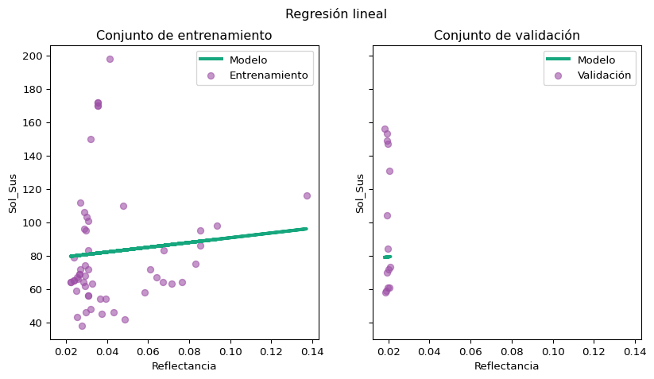

```python
fig, ax = plt.subplots(ncols=2, figsize=(10, 5), sharex=True, sharey=True)

# Gráfico entrenamiento
ax[0].plot(X_train, regressor.predict(X_train), linewidth=3, color="#17A77E", label="Modelo")
ax[0].scatter(X_train, y_train, label="Entrenamiento", color="#9D50A6", alpha=0.6)
ax[0].set(xlabel="Reflectancia", ylabel="Sol_Sus", title="Conjunto de entrenamiento")
ax[0].legend()

# Gráfico validación
ax[1].plot(X_test, y_pred, linewidth=3, color="#17A77E", label="Modelo")
ax[1].scatter(X_test, y_test, label="Validación", color="#9D50A6", alpha=0.6)
ax[1].set(xlabel="Reflectancia", ylabel="Sol_Sus", title="Conjunto de validación")
ax[1].legend()

fig.suptitle("Regresión lineal")

plt.show()
```

**📄 Nota técnica**

> `plt.subplots` crea una figura con uno o más ejes para dibujar. Permite organizar varios gráficos en una misma figura.

> `plot()` traza una línea continua. Se usa para mostrar la línea de regresión generada por el modelo.

> `scatter()` traza puntos individuales. Se usa para mostrar los datos reales y compararlos con la línea del modelo.

> `set()` configura etiquetas de ejes y títulos de los subgráficos.

> `legend()` muestra una leyenda que identifica cada elemento del gráfico.

> `fig.suptitle()` agrega un título general a la figura completa.

> `plt.show()` es necesario para visualizar los gráficos al renderizar el documento.

### 2.4 Regresión lineal individual por banda

Con el fin de profundizar el análisis, evalué la relación entre los **sólidos suspendidos (sol_sus)** y cada **banda espectral** por separado. Para esto, entrené un modelo de regresión lineal simple usando los mismos datos experimentales para cada banda.

Con este enfoque comparo la capacidad predictiva individual de cada banda mediante las métricas `R²`, `R²` ajustado y el error cuadrático medio (`RMSE`). Este análisis me permite identificar qué bandas tienen mejor relación lineal con los sólidos suspendidos y sentar la base para probar modelos más complejos.

**Código**

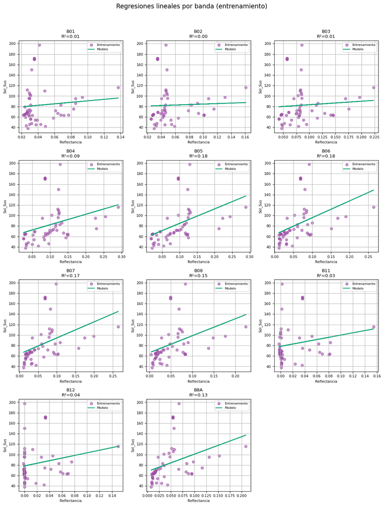

Tabla 3: Resumen de métricas por banda (entrenamiento)

| Banda | R² | R²_ajustado | RMSE |
| --- | --- | --- | --- |
| B05 | 0.183 | 0.167 | 33.457 |
| B06 | 0.180 | 0.164 | 33.523 |
| B07 | 0.173 | 0.157 | 33.651 |
| B08 | 0.146 | 0.130 | 34.191 |
| B8A | 0.135 | 0.118 | 34.429 |
| B04 | 0.094 | 0.076 | 35.230 |
| B12 | 0.038 | 0.019 | 36.303 |
| B11 | 0.033 | 0.015 | 36.389 |
| B01 | 0.008 | -0.011 | 36.865 |
| B03 | 0.005 | -0.014 | 36.917 |
| B02 | 0.001 | -0.018 | 36.985 |

```python
import pandas as pd
import numpy as np
from sklearn.model_selection import train_test_split
from sklearn.linear_model import LinearRegression
from sklearn.metrics import mean_squared_error
import matplotlib.pyplot as plt
import math
from IPython.display import display

# Cargar datos
datos = pd.read_csv('datos/datos_sol_sus_acolite.csv')

# Detectar columnas de bandas
bandas = [col for col in datos.columns if col.startswith("B")]

# Lista para guardar resultados
resultados = []

# Parámetros para organización de gráficos
n_bandas = len(bandas)
ncols = 3  # Número de columnas de la grilla
nrows = math.ceil(n_bandas / ncols)  # Calculamos cuántas filas se necesitan

# Crear figura
fig, axs = plt.subplots(nrows=nrows, ncols=ncols, figsize=(12, 4 * nrows))
axs = axs.flatten()  # Asegura que podamos indexarlos como una lista

for i, banda in enumerate(bandas):
    # Variables
    X = datos[[banda]]
    y = datos["sol_sus"]

    # División entrenamiento/prueba
    X_train, X_test, y_train, y_test = train_test_split(X, y, test_size=0.2, shuffle=False)

    # Ajuste del modelo
    modelo = LinearRegression().fit(X_train, y_train)
    y_train_pred = modelo.predict(X_train)

    # Métricas
    r2 = modelo.score(X_train, y_train)
    n = len(y_train)
    p = X_train.shape[1]
    r2_adj = 1 - (1 - r2) * (n - 1) / (n - p - 1)
    rmse = np.sqrt(mean_squared_error(y_train, y_train_pred))

    resultados.append({
        "Banda": banda,
        "R²": round(r2, 4),
        "R²_ajustado": round(r2_adj, 4),
        "RMSE": round(rmse, 4)
    })

    # Gráfico de entrenamiento
    ax = axs[i]
    ax.scatter(X_train, y_train, alpha=0.6, color="#9D50A6", label="Entrenamiento")
    ax.plot(X_train, y_train_pred, color="#17A77E", linewidth=1.8, label="Modelo")
    ax.set_title(f'{banda}\nR²={r2:.2f}', fontsize=10)
    ax.set_xlabel('Reflectancia', fontsize=8)
    ax.set_ylabel('Sol_Sus', fontsize=8)
    ax.tick_params(axis='both', which='major', labelsize=8)
    ax.legend(fontsize=7)
    ax.grid(True)

# Eliminar ejes sobrantes
for j in range(i + 1, len(axs)):
    fig.delaxes(axs[j])

plt.suptitle("Regresiones lineales por banda (entrenamiento)", fontsize=14)
plt.tight_layout(rect=[0, 0, 1, 0.96])
plt.show()

# Tabla resumen
df_resultados = (
    pd.DataFrame(resultados)
      .round(3)
      .sort_values("R²", ascending=False)   # la mejor banda queda arriba
      .reset_index(drop=True)
)

def style_metrics(df: pd.DataFrame, caption: str):
    sty = (
        df.style
          .format(precision=3)
    )

    # Ocultar índice según versión de pandas
    if hasattr(sty, "hide"):
        sty = sty.hide(axis="index")
    else:
        sty = sty.hide_index()

    # Agregar título y estilo del título
    sty = sty.set_caption(caption)
    sty = sty.set_table_styles([{
        "selector": "caption",
        "props": [
            ("caption-side", "top"),
            ("font-weight",  "bold"),
            ("margin-bottom", "0.5em")
        ]
    }], overwrite=False)

    return sty

# Mostrar tabla
display(style_metrics(df_resultados,
                      "Resumen de métricas por banda (entrenamiento)"))
```

**Conclusiones del análisis por banda**

Los resultados muestran que ninguna banda espectral logra predecir con alta precisión los sólidos suspendidos mediante un modelo lineal simple.

Las bandas **B05**, **B06** y **B07** presentan los mejores valores de `R²` (alrededor de 0.18), lo que indica que explican menos del 20 % de la variabilidad en los datos. El resto de las bandas tienen un desempeño aún menor, con errores (`RMSE`) relativamente altos en comparación con los valores observados.

Esto sugiere que la relación entre reflectancia y sólidos suspendidos no es lineal en escala natural y que será necesario explorar modelos más complejos o transformaciones de datos para mejorar la predicción.

### 2.5 Análisis de regresión lineal con transformación logarítmica

En esta etapa aplico una transformación logarítmica natural a las variables de reflectancia y sólidos suspendidos antes de ajustar los modelos de regresión lineal. Esta transformación permite estabilizar la varianza, linealizar relaciones no lineales y reducir el impacto de valores extremos.

El procedimiento es similar al análisis anterior, pero antes de entrenar el modelo se aplica `log(x)` a las columnas correspondientes. Para evitar problemas con valores cero, estos se reemplazan por `NaN` y se excluyen del análisis. Posteriormente, entreno modelos de regresión lineal simple por banda usando las variables transformadas.

El desempeño de cada modelo se evalúa mediante métricas en escala logarítmica (`R²_log`, `RMSE_log`) y en escala original, facilitando la comparación y la interpretación de resultados.

**Código**

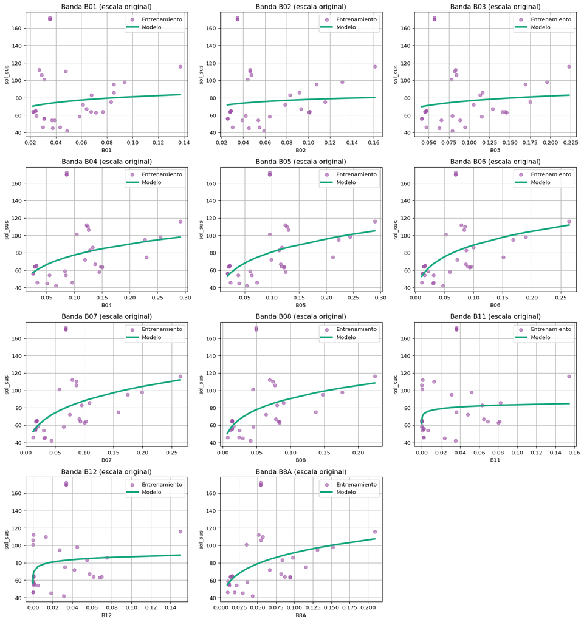

Tabla 4: Métricas en escala log‑log (ordenadas por RMSE_log)

| Banda | R²_log | R²aj_log | RMSE_log |
| --- | --- | --- | --- |
| B06 | 0.304 | 0.281 | 0.318 |
| B07 | 0.303 | 0.280 | 0.319 |
| B05 | 0.272 | 0.248 | 0.326 |
| B08 | 0.267 | 0.243 | 0.327 |
| B8A | 0.262 | 0.237 | 0.328 |
| B04 | 0.166 | 0.138 | 0.349 |
| B12 | 0.111 | 0.082 | 0.360 |
| B11 | 0.065 | 0.034 | 0.369 |
| B03 | 0.017 | -0.016 | 0.378 |
| B01 | 0.015 | -0.018 | 0.379 |
| B02 | 0.007 | -0.026 | 0.380 |

Tabla 5: Métricas en escala original (ordenadas por RMSE)

| Banda | R² | R²aj | RMSE |
| --- | --- | --- | --- |
| B06 | 0.198 | 0.171 | 31.661 |
| B07 | 0.186 | 0.159 | 31.897 |
| B05 | 0.178 | 0.150 | 32.049 |
| B8A | 0.156 | 0.128 | 32.472 |
| B08 | 0.151 | 0.123 | 32.567 |
| B04 | 0.077 | 0.046 | 33.962 |
| B12 | 0.076 | 0.045 | 33.986 |
| B11 | 0.043 | 0.011 | 34.576 |
| B01 | -0.028 | -0.063 | 35.843 |
| B03 | -0.034 | -0.068 | 35.940 |
| B02 | -0.035 | -0.070 | 35.969 |

```python
import pandas as pd
import numpy as np
import matplotlib.pyplot as plt
from sklearn.model_selection import train_test_split
from sklearn.linear_model import LinearRegression
from sklearn.metrics import mean_squared_error, r2_score
import math
import seaborn as sns
from IPython.display import display

# 1. ── Cargar datos ────────────────────────────────────────────────
datos = pd.read_csv("datos/datos_sol_sus_acolite.csv")
bandas = [c for c in datos.columns if c.startswith("B")]

# 2. ── Filtrar positivos (requisito para log) ──────────────────────
mask_pos   = (datos["sol_sus"] > 0) & (datos[bandas] > 0).all(axis=1)
datos_log  = datos.loc[mask_pos].copy()

# 3. ── Transformar a log-natural ──────────────────────────────────
datos_log["log_sol_sus"] = np.log(datos_log["sol_sus"])
for b in bandas:
    datos_log[f"log_{b}"] = np.log(datos_log[b])

log_bandas = [f"log_{b}" for b in bandas]

# 4. ── Train / test split (descartamos test) ───────────────────────
X_total = datos_log[log_bandas]
y_total = datos_log["log_sol_sus"]
X_train, _, y_train, _ = train_test_split(
    X_total, y_total, test_size=0.2, shuffle=False)

# 5. ── Funciones de métricas ───────────────────────────────────────
def metrics_log(model, X, y):
    y_pred = model.predict(X)
    rmse   = np.sqrt(mean_squared_error(y, y_pred))
    r2     = r2_score(y, y_pred)
    n, p   = X.shape
    r2_adj = 1 - ((1 - r2) * (n - 1)) / (n - p - 1)
    return rmse, r2, r2_adj

def metrics_original(model, X, y):
    y_pred_log  = model.predict(X).ravel()
    y_pred_orig = np.exp(y_pred_log)
    y_true_orig = np.exp(y.values)
    rmse   = np.sqrt(mean_squared_error(y_true_orig, y_pred_orig))
    r2     = r2_score(y_true_orig, y_pred_orig)
    n, p   = X.shape
    r2_adj = 1 - ((1 - r2) * (n - 1)) / (n - p - 1)
    return rmse, r2, r2_adj

# 6. ── Entrenar un modelo por banda ────────────────────────────────
resultados, resultados_nolog = [], []
lineas_log, lineas_nolog     = {}, {}

for b, lb in zip(bandas, log_bandas):
    Xtr = X_train[[lb]]
    reg = LinearRegression().fit(Xtr, y_train)

    # Métricas en log
    rmse_l, r2_l, r2a_l = metrics_log(reg, Xtr, y_train)
    resultados.append({"Banda": b, "R²_log": r2_l,
                    "R²aj_log": r2a_l, "RMSE_log": rmse_l})

    # Métricas en original
    rmse_o, r2_o, r2a_o = metrics_original(reg, Xtr, y_train)
    resultados_nolog.append({"Banda": b,
                             "R²": r2_o, "R²aj": r2a_o, "RMSE": rmse_o})

    # Rectas ordenadas
    order        = np.argsort(Xtr.values.ravel())
    x_log_ord    = Xtr.values.ravel()[order]
    y_pred_log   = reg.predict(Xtr).ravel()[order]
    lineas_log[b] = (x_log_ord, y_pred_log)

    x_orig_ord   = np.exp(x_log_ord)
    y_pred_orig  = np.exp(y_pred_log)
    lineas_nolog[b] = (x_orig_ord, y_pred_orig)

# 7. ── DataFrames de métricas ──────────────────────────────────────
res_df_log   = (pd.DataFrame(resultados)
                  .round(3)
                  .sort_values("RMSE_log")
                  .reset_index(drop=True))

res_df_nolog = (pd.DataFrame(resultados_nolog)
                  .round(3)
                  .sort_values("RMSE")
                  .reset_index(drop=True))

# 8. ── Gráficos en escala original ────────────────────────────────
n_cols, n_rows = 3, math.ceil(len(bandas) / 3)
fig, axes = plt.subplots(n_rows, n_cols, figsize=(15, 4 * n_rows))
axes = axes.flatten()

for idx, b in enumerate(bandas):
    ax = axes[idx]
    x_orig = np.exp(X_train[f"log_{b}"])
    y_orig = np.exp(y_train)
    ax.scatter(x_orig, y_orig, alpha=0.6, color="#9D50A6", label="Entrenamiento")
    ax.plot(*lineas_nolog[b], lw=3, color="#17A77E", label="Modelo")
    ax.set(xlabel=b, ylabel="sol_sus", title=f"Banda {b} (escala original)")
    ax.legend()
    ax.grid(True)

for j in range(len(bandas), len(axes)):
    fig.delaxes(axes[j])

plt.tight_layout()
plt.show()

# 9. ── Función para estilo de tablas ───────────────────────────────
def style_metrics_sin_gradiente(df: pd.DataFrame, caption: str):
    sty = (df.style
             .format(precision=3)
             # .background_gradient(...) ← quitamos el gradiente
             .hide(axis="index")
             .set_caption(caption)
             .set_table_styles([{
                 "selector": "caption",
                 "props": [("caption-side", "top"),
                           ("font-weight",  "bold"),
                           ("margin-bottom","0.5em")]
             }], overwrite=False)
          )
    return sty


# 10 ── Mostrar tablas con el nuevo estilo pastel ───────────────────────────────
display(style_metrics_sin_gradiente(res_df_log,
        "Métricas en escala log‑log (ordenadas por RMSE_log)"))

display(style_metrics_sin_gradiente(res_df_nolog,
        "Métricas en escala original (ordenadas por RMSE)"))
```

**📄 Nota técnica**

> La transformación `log(x)` se usa frecuentemente cuando la relación entre variables es multiplicativa o cuando hay asimetría en la distribución.

> Es fundamental reemplazar ceros por NaN antes de aplicar el logaritmo, ya que `log(0)` no está definido.

> Las métricas obtenidas (`R²` y `RMSE`) se interpretan en la **escala logarítmica y no son directamente** comparables con las obtenidas en la escala original.

> El `R² ajustado` penaliza la complejidad del modelo y ayuda a evaluar si el ajuste mejora más allá de lo que se esperaría por azar.

**Conclusión del ajuste log–log por banda**

Los resultados muestran que al aplicar la transformación logarítmica, las bandas **B06**, **B07** y **B05** obtienen los mejores ajustes, con valores de `R²_log` cercanos a 0.30 y errores (`RMSE_log`) más bajos comparados con las demás bandas. Esto indica una mejora en la capacidad predictiva respecto al análisis en escala natural.

Sin embargo, al evaluar las métricas en escala original, el mejor desempeño alcanza un `R²` máximo cercano a 0.20, lo que aún refleja una capacidad limitada para explicar la variabilidad de los sólidos suspendidos utilizando bandas individuales.

Estos resultados sugieren que la transformación logarítmica mejora el modelo, pero que para obtener predicciones más precisas será necesario explorar combinaciones de bandas, índices espectrales o modelos más complejos.

### 2.6 Selección de bandas mediante regresión logarítmica y AIC

Para determinar cuáles bandas espectrales aportan más información para predecir sólidos suspendidos, ajusté modelos de regresión lineal simple en escala logarítmica para cada banda individual. Además de las métricas habituales como el coeficiente de determinación (`R²`) y el error cuadrático medio (`RMSE`), utilicé el **Criterio de Información de Akaike (AIC)**.

El AIC es una medida que evalúa la calidad del modelo penalizando la complejidad: un valor menor indica un mejor equilibrio entre ajuste y simplicidad. Esto ayuda a evitar sobreajuste al no favorecer modelos que mejoran el ajuste sólo por aumentar el número de parámetros sin aportar realmente información útil. Así, el AIC es una herramienta clave para seleccionar las bandas que efectivamente mejoran la predicción sin agregar complejidad innecesaria.

**Código**

```python
import pandas as pd
import numpy as np
from sklearn.model_selection import train_test_split
from sklearn.linear_model import LinearRegression
from sklearn.metrics import mean_squared_error, r2_score
import seaborn as sns
from IPython.display import display

# 1. Cargar datos y detectar bandas
datos = pd.read_csv("datos/datos_sol_sus_acolite.csv")
bandas = [c for c in datos.columns if c.startswith("B")]

# 2. Filtrar casos con valores positivos (requisito de log)
mask_pos = (datos["sol_sus"] > 0) & (datos[bandas] > 0).all(axis=1)
datos_log = datos.loc[mask_pos].copy()

# 3. Transformar a log-natural
datos_log["log_sol_sus"] = np.log(datos_log["sol_sus"])
for b in bandas:
    datos_log[f"log_{b}"] = np.log(datos_log[b])

log_bandas = [f"log_{b}" for b in bandas]

# 4. Partición entrenamiento / test
X_total = datos_log[log_bandas]
y_total = datos_log["log_sol_sus"]

X_train, _, y_train, _ = train_test_split(
    X_total, y_total, test_size=0.20, shuffle=False
)

# 5. Funciones auxiliares (AIC + métricas)
def aic_gauss(model, X, y):
    """
    AIC para regresión lineal con ruido ~ N(0, σ²)
    AIC = n · ln(RSS/n) + 2k
    """
    n = len(y)
    k = X.shape[1] + 1  # predictores + intercepto
    rss = np.sum((y - model.predict(X)) ** 2)
    return n * np.log(rss / n) + 2 * k

def metrics_log(model, X, y):
    y_pred = model.predict(X)
    rmse = np.sqrt(mean_squared_error(y, y_pred))
    r2   = r2_score(y, y_pred)
    n, p = X.shape
    r2_adj = 1 - ((1 - r2) * (n - 1)) / (n - p - 1)
    return rmse, r2, r2_adj

# 6. Ajuste univariable banda-a-banda + AIC
resultados = []

for b in bandas:
    lb = f"log_{b}"
    Xtr = X_train[[lb]]
    reg = LinearRegression().fit(Xtr, y_train)

    rmse_log, r2_log, r2a_log = metrics_log(reg, Xtr, y_train)
    aic_val = aic_gauss(reg, Xtr, y_train)

    resultados.append({
        "Banda"    : b,
        "R²_log"   : r2_log,
        "R²aj_log" : r2a_log,
        "RMSE_log" : rmse_log,
        "AIC"      : aic_val
    })

# 7. Tabla ordenada por AIC
df_log  = (pd.DataFrame(resultados)
             .round(3)
             .sort_values("AIC")
             .reset_index(drop=True))

def style_metrics_sin_gradiente(df: pd.DataFrame, caption: str):
    sty = (df.style
             .format(precision=3)
             .hide(axis="index")  # oculta índice
             .set_caption(caption)
             .set_table_styles([{
                 "selector": "caption",
                 "props": [("caption-side", "top"),
                           ("font-weight",  "bold"),
                           ("margin-bottom", "0.5em")]
             }], overwrite=False)
          )
    return sty

# 9 ── Mostrar tabla con el nuevo estilo pastel AIC ───────────────────────────
display(style_metrics_sin_gradiente(
    df_log, "AIC y métricas en escala log‑log (ordenadas por AIC)"
))
```

Tabla 6: AIC y métricas en escala log‑log (ordenadas por AIC)

| Banda | R²_log | R²aj_log | RMSE_log | AIC |
| --- | --- | --- | --- | --- |
| B06 | 0.304 | 0.281 | 0.318 | -69.242 |
| B07 | 0.303 | 0.280 | 0.319 | -69.191 |
| B05 | 0.272 | 0.248 | 0.326 | -67.798 |
| B08 | 0.267 | 0.243 | 0.327 | -67.584 |
| B8A | 0.262 | 0.237 | 0.328 | -67.355 |
| B04 | 0.166 | 0.138 | 0.349 | -63.448 |
| B12 | 0.111 | 0.082 | 0.360 | -61.415 |
| B11 | 0.065 | 0.034 | 0.369 | -59.781 |
| B03 | 0.017 | -0.016 | 0.378 | -58.184 |
| B01 | 0.015 | -0.018 | 0.379 | -58.112 |
| B02 | 0.007 | -0.026 | 0.380 | -57.878 |

**Conclusión sobre la selección de bandas con AIC**

Los valores obtenidos muestran que las bandas **B06** y **B07** son las más relevantes para predecir los sólidos suspendidos, ya que presentan los valores más bajos de AIC (-69.24 y -69.19 respectivamente), indicando el mejor equilibrio entre calidad de ajuste y simplicidad del modelo.  
Estas bandas también exhiben los mejores coeficientes de determinación (`R²_log` alrededor de 0.30) y los menores errores (`RMSE_log` cerca de 0.32).

El resto de las bandas tienen valores de AIC menos favorables, lo que sugiere que, individualmente, aportan menos información útil y no justifican la complejidad del modelo. Esto refuerza la idea de que para mejorar las predicciones será necesario combinar varias bandas o explorar modelos más complejos.

#### 2.6.1 Selección de banda espectral con validación cruzada

En esta sección selecciono la banda espectral más adecuada para estimar los **sólidos suspendidos (sol_sus)** usando un modelo de regresión lineal simple en escala logarítmica. A diferencia de análisis anteriores, ahora incorporo una validación cruzada que respeta la estructura temporal de los datos, para asegurar que el modelo sea confiable al aplicarse a nuevas campañas de muestreo.

**¿Por qué validación Leave-One-Group-Out (LOGO)?**

Los datos provienen de campañas realizadas en diferentes fechas (`fecha`). Esto genera grupos independientes, ya que las condiciones del río pueden variar entre campañas. Usar una validación cruzada tradicional como K-Fold o Shuffle Split mezclaría muestras de una misma campaña entre entrenamiento y prueba, lo que daría una estimación demasiado optimista del desempeño.

En cambio, `LeaveOneGroupOut` (LOGO) deja **una fecha completa afuera en cada iteración**, lo que permite evaluar si el modelo puede **generalizar a campañas no vistas**. Esta estrategia evita **filtraciones de información** (*data leakage*) entre los datos de entrenamiento y validación, y resulta mucho más realista en contextos ambientales, donde el objetivo es predecir nuevas campañas a partir de mediciones anteriores.

**Descripción del procedimiento:**

- **Preprocesamiento**: aplico `log()` a las bandas y a la variable objetivo (`sol_sus`) y elimino ceros, para linearizar y estabilizar la relación.
- **Modelado**: ajusto un modelo de regresión lineal simple por cada banda, normalizando los datos con `StandardScaler` (pipeline). Para cada modelo calculo las métricas de validación cruzada: `RMSE`, `R²`, `R² ajustado` y el `AIC`, que penaliza la complejidad del modelo.
- **Selección**: ordeno las bandas por AIC y RMSE, y elijo la mejor.
- **Evaluación final**:
  - Estimo el desempeño real sobre la campaña más reciente (test).
  - Realizo un análisis **bootstrap** (500 réplicas) para obtener intervalos de confianza de los parámetros y métricas.
  - Muestro gráficos de predicho vs observado en escala log y original.

Este enfoque no solo me permite elegir la **banda más informativa**, sino que también evalúa la **estabilidad** del modelo y su capacidad de **generalizar en el tiempo**, algo clave para el monitoreo operativo de calidad de agua.

**Código**

Tabla 7: Ranking por AIC (TRAIN, log)

| Banda | AIC | RMSE_CV | R2_CV | AdjR2_CV |
| --- | --- | --- | --- | --- |
| B07 | -85.218 | 0.291 | -79.607 | nan |
| B08 | -84.907 | 0.285 | -77.085 | nan |
| B06 | -84.048 | 0.298 | -79.242 | nan |
| B05 | -82.491 | 0.325 | -77.426 | nan |
| B8A | -81.287 | 0.310 | -99.788 | nan |
| B04 | -79.479 | 0.340 | -96.472 | nan |
| B03 | -74.454 | 0.341 | -146.625 | nan |
| B02 | -72.724 | 0.344 | -163.983 | nan |
| B01 | -70.995 | 0.342 | -163.197 | nan |
| B12 | -69.509 | 0.332 | -160.438 | nan |
| B11 | -68.415 | 0.317 | -147.291 | nan |

**Mejor banda:** `B07`

**Ecuación log:**

`log(sol_sus) = 4.2330 + 0.1938·log(B07)`

**Escala real:**

`sol_sus = 68.9254 · B07^0.1938`

Tabla 8: Desempeño en TEST

| Métrica | Log | Real (mg/L) |
| --- | --- | --- |
| RMSE | 0.645 | 70.77 |
| R² | -1.172 | -1.326 |
| R² ajustado | -1.389 | -1.558 |

Tabla 9: Bootstrap (500 réplicas) · IC 95%

| Parámetro / Métrica | Promedio | IC 95% inf. | IC 95% sup. |
| --- | --- | --- | --- |
| Intercepto | 4.2458 | 4.1789 | 4.3614 |
| Coef B07 | 0.1911 | 0.0600 | 0.2917 |
| RMSE (log) | 0.2440 | 0.2148 | 0.3839 |
| R² (log) | 0.2398 | -0.7610 | 0.4489 |
| R² ajustado (log) | 0.2117 | -0.8263 | 0.4285 |
| RMSE (mg/L) | 18.50 | 15.86 | 34.59 |
| R² (mg/L) | 0.1584 | -1.5746 | 0.4585 |
| R² ajustado (mg/L) | 0.1272 | -1.6700 | 0.4384 |

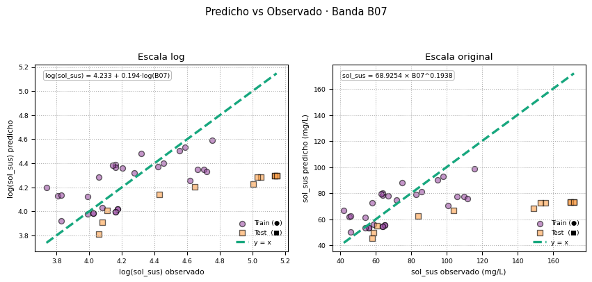

```python
# -------------------------------------------------------------
# 0 · LIBRERÍAS
import numpy as np
import pandas as pd
from pathlib import Path
import matplotlib.pyplot as plt
from sklearn.linear_model import LinearRegression
from sklearn.preprocessing import StandardScaler
from sklearn.pipeline import Pipeline
from sklearn.model_selection import LeaveOneGroupOut
from sklearn.metrics import mean_squared_error, r2_score
from IPython.display import display, Markdown

# ----------  ESTÉTICA TABLAS (sin gradiente) ------------------
def style_table(df, caption):
    return (df.style
              .format(precision=3)
              .hide(axis="index")
              .set_caption(caption)
              .set_table_styles([
                 {"selector": "caption",
                  "props": [("caption-side", "top"),
                            ("font-weight",  "bold"),
                            ("margin-bottom","0.5em"),
                            ("text-align","left")]},
                 {"selector": "th",
                  "props": [("text-align","center")]},
                 {"selector": "td",
                  "props": [("text-align","right"),
                            ("padding","0.25em 0.5em")]}
              ], overwrite=False))

# -------------------------------------------------------------
# 1 · CARGA Y PREPARACIÓN
csv_file = Path("datos/datos_sol_sus_acolite.csv")
df = pd.read_csv(csv_file).drop_duplicates()
df["fecha"] = pd.to_datetime(df["fecha"])

bandas = [c for c in df.columns if c.startswith("B")]
mask   = (df["sol_sus"]>0) & (df[bandas]>0).all(axis=1)
df     = df.loc[mask].copy()

df["log_sol_sus"] = np.log(df["sol_sus"])
for b in bandas: df[f"log_{b}"] = np.log(df[b])

log_cols = [f"log_{b}" for b in bandas]
X_total  = df[log_cols];     y_total = df["log_sol_sus"]

last_date   = df["fecha"].max()
mask_test   = df["fecha"]==last_date
mask_train  = ~mask_test
X_train,y_train = X_total[mask_train],y_total[mask_train]
X_test ,y_test  = X_total[mask_test ],y_total[mask_test ]
grupos_train    = df.loc[mask_train,"fecha"]

# -------------------------------------------------------------
# 2 · AUXILIARES
adj_r2 = lambda r2,n,p: np.nan if n-p-1<=0 else 1-(1-r2)*(n-1)/(n-p-1)
rmse   = lambda a,b: np.sqrt(mean_squared_error(a,b))
def aic_gauss(m,X,y):
    n,k=len(y),X.shape[1]+1
    rss=np.sum((y-m.predict(X))**2)
    return n*np.log(rss/n)+2*k

# -------------------------------------------------------------
# 3 · SELECCIÓN DE BANDA (AIC + LOGO)
cv = LeaveOneGroupOut()
res = []
for b in bandas:
    lb, Xb_tr = f"log_{b}", X_train[[f"log_{b}"]]
    pipe = Pipeline([("s",StandardScaler()),("m",LinearRegression())]).fit(Xb_tr,y_train)
    aic  = aic_gauss(pipe.named_steps["m"],pipe.named_steps["s"].transform(Xb_tr),y_train)
    rm,r2,ra = [],[],[]
    for tr,te in cv.split(Xb_tr,y_train,grupos_train):
        mdl = Pipeline([("s",StandardScaler()),("m",LinearRegression())]).fit(Xb_tr.iloc[tr],y_train.iloc[tr])
        pred = mdl.predict(Xb_tr.iloc[te])
        rm.append(rmse(y_train.iloc[te],pred))
        r2_ = r2_score(y_train.iloc[te],pred)
        r2.append(r2_); ra.append(adj_r2(r2_,len(te),1))
    res.append({"Banda":b,"AIC":aic,
                "RMSE_CV":np.mean(rm),"R2_CV":np.mean(r2),"AdjR2_CV":np.mean(ra)})

tbl = (pd.DataFrame(res).sort_values(["AIC","RMSE_CV"]).round(4).reset_index(drop=True))
display(style_table(tbl,"Ranking por AIC (TRAIN, log)"))

best_band = tbl.loc[0,"Banda"]
display(Markdown(f"**Mejor banda:** `{best_band}`"))

# -------------------------------------------------------------
# 4 · MODELO FINAL
lb_best   = f"log_{best_band}"
pipe_final= Pipeline([("s",StandardScaler()),("m",LinearRegression())]).fit(X_train[[lb_best]],y_train)
a,b_coef  = pipe_final.named_steps["m"].intercept_,pipe_final.named_steps["m"].coef_[0]
display(Markdown("**Ecuación log:**"));  display(Markdown(f"`log(sol_sus) = {a:.4f} + {b_coef:.4f}·log({best_band})`"))
display(Markdown("**Escala real:**"));   display(Markdown(f"`sol_sus = {np.exp(a):.4f} · {best_band}^{b_coef:.4f}`"))

# -------------------------------------------------------------
# 5 · MÉTRICAS TEST (tabla horizontal)
yhat_log  = pipe_final.predict(X_test[[lb_best]])
yhat_lin  = np.exp(yhat_log)
metrics_df = pd.DataFrame({
    "Métrica":["RMSE","R²","R² ajustado"],
    "Log":[rmse(y_test,yhat_log), r2_score(y_test,yhat_log), adj_r2(r2_score(y_test,yhat_log),len(y_test),1)],
    "Real (mg/L)":[rmse(np.exp(y_test),yhat_lin), r2_score(np.exp(y_test),yhat_lin),
                   adj_r2(r2_score(np.exp(y_test),yhat_lin),len(y_test),1)]
})
metrics_df["Log"] = metrics_df["Log"].apply(lambda x:f"{x:.3f}")
metrics_df["Real (mg/L)"]=metrics_df["Real (mg/L)"].apply(lambda x:f"{x:.3f}" if abs(x)<10 else f"{x:.2f}")
display(style_table(metrics_df,"Desempeño en TEST"))

# -------------------------------------------------------------
# 6 · BOOTSTRAP (tabla horizontal)
np.random.seed(123); n_boot=500; fechas=grupos_train.unique()
ib,cb,rm_l,r2_l,ra_l,rm_r,r2_r,ra_r=[],[],[],[],[],[],[],[]
for _ in range(n_boot):
    idx = grupos_train.isin(np.random.choice(fechas,len(fechas),replace=True))
    Xb,yb = X_train[[lb_best]].loc[idx],y_train.loc[idx]
    mdl = Pipeline([("s",StandardScaler()),("m",LinearRegression())]).fit(Xb,yb)
    ib.append(mdl.named_steps["m"].intercept_)
    cb.append(mdl.named_steps["m"].coef_[0])
    pr_log = mdl.predict(X_train[[lb_best]])
    rm_l.append(rmse(y_train,pr_log)); r2_l_ = r2_score(y_train,pr_log); r2_l.append(r2_l_)
    ra_l.append(adj_r2(r2_l_,len(y_train),1))
    pr_lin = np.exp(pr_log)
    rm_r.append(rmse(np.exp(y_train),pr_lin)); r2_r_ = r2_score(np.exp(y_train),pr_lin); r2_r.append(r2_r_)
    ra_r.append(adj_r2(r2_r_,len(y_train),1))

pct = lambda arr: np.percentile(arr,[2.5,97.5])
ci = { "inter":pct(ib), "coef":pct(cb),
       "rm_l":pct(rm_l),"r2_l":pct(r2_l),"ra_l":pct(ra_l),
       "rm_r":pct(rm_r),"r2_r":pct(r2_r),"ra_r":pct(ra_r)}

bs_df = pd.DataFrame({
    "Parámetro / Métrica":[
        "Intercepto",f"Coef {best_band}",
        "RMSE (log)","R² (log)","R² ajustado (log)",
        "RMSE (mg/L)","R² (mg/L)","R² ajustado (mg/L)"
    ],
    "Promedio":[np.mean(ib),np.mean(cb),
                np.mean(rm_l),np.mean(r2_l),np.mean(ra_l),
                np.mean(rm_r),np.mean(r2_r),np.mean(ra_r)],
    "IC 95% inf.":[ci["inter"][0],ci["coef"][0],
                   ci["rm_l"][0],ci["r2_l"][0],ci["ra_l"][0],
                   ci["rm_r"][0],ci["r2_r"][0],ci["ra_r"][0]],
    "IC 95% sup.":[ci["inter"][1],ci["coef"][1],
                   ci["rm_l"][1],ci["r2_l"][1],ci["ra_l"][1],
                   ci["rm_r"][1],ci["r2_r"][1],ci["ra_r"][1]]
})
for col in bs_df.columns[1:]:
    bs_df[col] = bs_df[col].apply(lambda x:f"{x:.4f}" if abs(float(x))<10 else f"{x:.2f}")
display(style_table(bs_df,"Bootstrap (500 réplicas) · IC 95%"))

# -------------------------------------------------------------
# 7 · GRÁFICO Predicho vs Observado  (Train + Test)
#     Izquierda → escala log   ·   Derecha → escala original
plt.rcParams.update({"axes.titlesize":10, "axes.labelsize":8,
                     "xtick.labelsize":7, "ytick.labelsize":7})

TRAIN_CLR = "#9D50A6"   # violeta
TEST_CLR  = "#FFA24B"   # naranja
ID_CLR    = "#17A77E"   # línea identidad

# --- predicciones ---
y_train_log_pred = pipe_final.predict(X_train[[lb_best]])
y_test_log_pred  = pipe_final.predict(X_test [[lb_best]])
y_train_orig, y_train_pred = np.exp(y_train), np.exp(y_train_log_pred)
y_test_orig , y_test_pred  = np.exp(y_test ), np.exp(y_test_log_pred)

fig, ax = plt.subplots(1, 2, figsize=(9, 4), sharex=False, sharey=False)

#  Escala log
ax[0].scatter(y_train, y_train_log_pred, alpha=0.6,
              color=TRAIN_CLR, edgecolor="k", label="Train (●)")
ax[0].scatter(y_test , y_test_log_pred , alpha=0.6,
              color=TEST_CLR , marker="s", edgecolor="k", label="Test  (■)")

lims = [min(y_train.min(), y_test.min()),
        max(y_train.max(), y_test.max())]
ax[0].plot(lims, lims, "--", color=ID_CLR, lw=2.5, label="y = x")
ax[0].set_xlabel("log(sol_sus) observado")
ax[0].set_ylabel("log(sol_sus) predicho")
ax[0].set_title("Escala log")
ax[0].legend(fontsize=7, frameon=False)
ax[0].grid(ls=":")

eq_log_txt = f"log(sol_sus) = {a:.3f} + {b_coef:.3f}·log({best_band})"
ax[0].text(0.04, 0.96, eq_log_txt, transform=ax[0].transAxes,
           fontsize=7, va="top",
           bbox=dict(boxstyle="round,pad=0.25", fc="white", ec="gray", lw=0.4))

#  Escala original
ax[1].scatter(y_train_orig, y_train_pred, alpha=0.6,
              color=TRAIN_CLR, edgecolor="k", label="Train (●)")
ax[1].scatter(y_test_orig , y_test_pred , alpha=0.6,
              color=TEST_CLR , marker="s", edgecolor="k", label="Test  (■)")

lims_o = [min(y_train_orig.min(), y_test_orig.min(),
              y_train_pred.min(), y_test_pred.min()),
          max(y_train_orig.max(), y_test_orig.max(),
              y_train_pred.max(), y_test_pred.max())]
ax[1].plot(lims_o, lims_o, "--", color=ID_CLR, lw=2.5, label="y = x")
ax[1].set_xlabel("sol_sus observado (mg/L)")
ax[1].set_ylabel("sol_sus predicho (mg/L)")
ax[1].set_title("Escala original")
ax[1].legend(fontsize=7, frameon=False)
ax[1].grid(ls=":")

eq_orig_txt = f"sol_sus = {np.exp(a):.4f} × {best_band}^{b_coef:.4f}"
ax[1].text(0.04, 0.96, eq_orig_txt, transform=ax[1].transAxes,
           fontsize=7, va="top",
           bbox=dict(boxstyle="round,pad=0.25", fc="white", ec="gray", lw=0.4))

fig.suptitle(f"Predicho vs Observado · Banda {best_band}", fontsize=11, y=1.05)
fig.tight_layout(pad=1.2)
plt.show()

# (opcional) restaurar tamaños por si sigues graficando después
plt.rcParams.update({"axes.titlesize":11, "axes.labelsize":9,
                     "xtick.labelsize":8, "ytick.labelsize":8})
```

**Conclusión del modelo con validación cruzada**

Sin embargo, al evaluar el modelo con los datos más recientes (campaña de prueba), el desempeño cae considerablemente. El `R²` es negativo, lo que significa que el modelo predice peor que una estimación promedio constante. En otras palabras, **el modelo no generaliza bien a nuevos datos**.

Para tener una idea más completa de su estabilidad, aplico la técnica de **bootstrap** con 500 repeticiones. Esto muestra que si bien el coeficiente de la banda B07 es consistentemente positivo (lo que confirma una relación), el rendimiento general del modelo es bajo y muy variable.

Concluyo que, aunque B07 es la mejor banda individual, **no alcanza para predecir sólidos suspendidos con precisión**. Para mejorar el modelo, es necesario combinar varias bandas, usar índices espectrales o aplicar modelos más complejos.

### 2.7 Selección de bandas con Forward Selection basado en AIC

En esta sección realizo la selección de un conjunto de bandas espectrales para predecir la concentración de **sólidos suspendidos (sol_sus)** mediante un modelo de regresión lineal múltiple en escala logarítmica. Utilizo el método de **Forward Selection** guiado por el **criterio de información de Akaike (AIC)**, que permite incorporar progresivamente aquellas bandas cuya inclusión mejora significativamente el ajuste del modelo sin incrementar de forma innecesaria su complejidad.

En esta sección selecciono un conjunto de bandas espectrales para predecir los **sólidos suspendidos (sol_sus)** mediante regresión lineal múltiple en escala logarítmica. Utilizo el método de **Forward Selection**, que comienza con un modelo vacío e incorpora progresivamente las bandas que más reducen el **AIC**, siempre que la mejora sea significativa (ΔAIC ≥ 1).

Finalmente, ajusto el modelo con las bandas seleccionadas, calculo métricas en train y test, y realizo un análisis bootstrap para obtener intervalos de confianza de los coeficientes. Esto me permite construir un modelo interpretable, robusto y ajustado a las condiciones reales del monitoreo ambiental.

**Código**

```
TRAIN campañas : 5
TEST  campaña  : 2025-06-09 (12 muestras)
```

**Paso 1 - candidatos:**

| Banda | AIC | ΔAIC |
| --- | --- | --- |
| B07 | -85.218 | 15.280 |
| B08 | -84.907 | 14.970 |
| B06 | -84.048 | 14.110 |
| B05 | -82.491 | 12.553 |
| B8A | -81.287 | 11.350 |
| B04 | -79.479 | 9.542 |
| B03 | -74.454 | 4.517 |
| B02 | -72.724 | 2.787 |
| B01 | -70.994 | 1.057 |
| B12 | -69.509 | -0.429 |
| B11 | -68.415 | -1.523 |

**Paso 2 - candidatos:**

| Banda | AIC | ΔAIC |
| --- | --- | --- |
| B02 | -108.017 | 22.799 |
| B01 | -99.457 | 14.240 |
| B03 | -97.017 | 11.799 |
| B11 | -95.445 | 10.228 |
| B12 | -88.549 | 3.332 |
| B8A | -87.786 | 2.568 |
| B06 | -85.179 | -0.039 |
| B04 | -84.967 | -0.251 |
| B05 | -83.319 | -1.899 |
| B08 | -83.234 | -1.984 |

**Paso 3 - candidatos:**

| Banda | AIC | ΔAIC |
| --- | --- | --- |
| B11 | -108.355 | 0.338 |
| B08 | -108.291 | 0.274 |
| B03 | -107.375 | -0.641 |
| B8A | -107.364 | -0.653 |
| B04 | -107.084 | -0.933 |
| B05 | -106.992 | -1.025 |
| B12 | -106.731 | -1.286 |
| B01 | -106.713 | -1.304 |
| B06 | -106.021 | -1.996 |

Tabla 10: Historial forward‑AIC

| Paso | Bandas | AIC | RMSE | R² | R²aj |
| --- | --- | --- | --- | --- | --- |
| 1 | B07 | -85.218 | 0.215 | 0.449 | 0.429 |
| 2 | B07, B02 | -108.017 | 0.140 | 0.766 | 0.748 |

**Bandas finales:** B07, B02

**GroupKFold CV (log) RMSE:** 0.125 ± 0.058

Tabla 11: Desempeño en Train y Test

| Métrica | Train log | Test log | Train orig | Test orig |
| --- | --- | --- | --- | --- |
| RMSE | 0.140 | 0.314 | 9.209 | 36.331 |
| R² | 0.766 | 0.484 | 0.817 | 0.387 |

Tabla 12: Bootstrap (coeficientes, 95 % CI)

| Banda | Media β | IC inf | IC sup |
| --- | --- | --- | --- |
| B07 | 0.635 | 0.429 | 0.713 |
| B02 | -0.698 | -0.881 | -0.141 |

**Bandas seleccionadas:**

`B07, B02`

**Ecuación en escala logarítmica:**

`log(sol_sus) = 3.9813 + 0.6438·log(B07) + -0.7532·log(B02)`

**Ecuación en escala original:**

`sol_sus = 53.5891 · B07^0.6438 · B02^-0.7532`

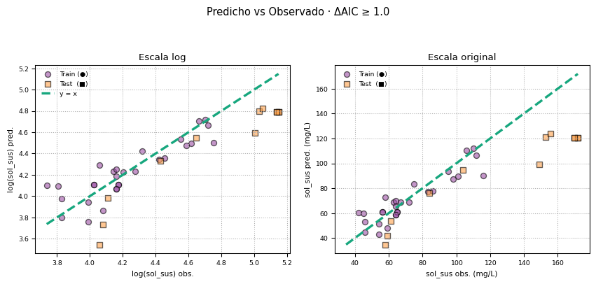

```python
import numpy as np
import pandas as pd
from pathlib import Path
from sklearn.linear_model import LinearRegression
from sklearn.model_selection import GroupKFold
from sklearn.metrics import mean_squared_error, r2_score
import matplotlib.pyplot as plt
from IPython.display import display, Markdown

# -------------------------------------------------------------
# 1 · CONFIGURACIÓN
DATOS      = Path("datos/datos_sol_sus_acolite.csv")
N_BOOT     = 2000
DELTA_AIC  = 1.0
RNG_SEED   = 42

# -------------------------------------------------------------
# 2 · ESTILO TABLAS (robusto a versiones pandas)
def style_table(df, caption):
    sty = df.style.format(precision=3)
    if hasattr(sty, "hide"):
        sty = sty.hide(axis="index")
    elif hasattr(sty, "hide_index"):
        sty = sty.hide_index()
    # caption + estilos de alineación
    sty = (sty.set_caption(caption)
              .set_table_styles([
                  {"selector":"caption","props":[("caption-side","top"),
                                                ("font-weight","bold"),
                                                ("margin-bottom","0.5em"),
                                                ("text-align","left")]},
                  {"selector":"th","props":[("text-align","center")]},
                  {"selector":"td","props":[("text-align","right"),
                                            ("padding","0.25em 0.5em")]}
              ], overwrite=False))
    return sty

# -------------------------------------------------------------
# 3 · FUNCIONES AUXILIARES
rmse = lambda a,b: np.sqrt(mean_squared_error(a,b))
aic_g = lambda rss,n,k: n*np.log(rss/n)+2*k
def fit_metrics(Xm, ym):
    m = LinearRegression().fit(Xm, ym)
    pred = m.predict(Xm)
    n,p = Xm.shape
    rss = np.sum((ym - pred)**2)
    return {"AIC":aic_g(rss,n,p+1),
            "RMSE":rmse(ym,pred),
            "R²":r2_score(ym,pred),
            "R²aj":1-(1-r2_score(ym,pred))*(n-1)/(n-p-1),
            "mod":m}

# -------------------------------------------------------------
# 4 · CARGA Y PREPARACIÓN
df = (pd.read_csv(DATOS)
        .sort_values("fecha")
        .reset_index(drop=True))
df["fecha"] = pd.to_datetime(df["fecha"])

bandas = [c for c in df.columns if c.startswith("B")]
mask   = (df["sol_sus"]>0) & (df[bandas]>0).all(axis=1)
df     = df.loc[mask].copy()

df["log_sol_sus"] = np.log(df["sol_sus"])
for b in bandas: df[f"log_{b}"] = np.log(df[b])

X = df[[f"log_{b}" for b in bandas]]; y = df["log_sol_sus"]

last_date = df["fecha"].max()
m_test    = df["fecha"]==last_date
m_train   = ~m_test

X_tr,y_tr = X[m_train],y[m_train]
X_te,y_te = X[m_test ],y[m_test ]
groups_tr = df.loc[m_train,"fecha"]

print(f"TRAIN campañas : {groups_tr.nunique()}")
print(f"TEST  campaña  : {last_date.date()} ({m_test.sum()} muestras)")

# -------------------------------------------------------------
# 5 · FORWARD SELECTION con tabla de candidatos
remaining, selected = list(X_tr.columns), []
rss_null  = np.sum((y_tr - y_tr.mean())**2)
best_aic  = aic_g(rss_null,len(y_tr),1)
hist=[]; paso=0

while remaining:
    cand=[]
    for b in remaining:
        mets = fit_metrics(X_tr[selected+[b]].values, y_tr.values)
        cand.append((mets["AIC"], b, mets))
    cand.sort()

    df_cand = pd.DataFrame({
        "Banda":[b.replace("log_","") for _,b,_ in cand],
        "AIC":[a for a,_,_ in cand]
    })
    df_cand["ΔAIC"] = best_aic - df_cand["AIC"]
    display(Markdown(f"**Paso {paso+1} - candidatos:**"))
    display(style_table(df_cand,""))

    new_aic,best_band,best_met = cand[0]
    if best_aic - new_aic >= DELTA_AIC:
        selected.append(best_band); remaining.remove(best_band)
        best_aic=new_aic; paso+=1
        hist.append({"Paso":paso,
                     "Bandas":", ".join(c.replace("log_","") for c in selected),
                     "AIC":best_aic,
                     "RMSE":best_met["RMSE"],
                     "R²":best_met["R²"],
                     "R²aj":best_met["R²aj"]})
    else:
        break

if not selected:
    selected=[cand[0][1]]; best_aic=cand[0][0]; best_met=cand[0][2]
    hist=[{"Paso":1,"Bandas":selected[0].replace("log_",""),
           "AIC":best_aic,"RMSE":best_met["RMSE"],
           "R²":best_met["R²"],"R²aj":best_met["R²aj"]}]

hist_df=pd.DataFrame(hist)[["Paso","Bandas","AIC","RMSE","R²","R²aj"]]
display(style_table(hist_df,"Historial forward‑AIC"))

sel_log=selected; sel=[c.replace("log_","") for c in sel_log]
display(Markdown(f"**Bandas finales:** {', '.join(sel)}"))

# -------------------------------------------------------------
# 6 · GroupKFold CV
gkf=GroupKFold(n_splits=min(5,groups_tr.nunique()))
rmse_cv=[rmse(y_tr.iloc[te],
              LinearRegression().fit(X_tr.iloc[tr][sel_log],y_tr.iloc[tr])
              .predict(X_tr.iloc[te][sel_log]))
         for tr,te in gkf.split(X_tr[sel_log],y_tr,groups_tr)]
display(Markdown(f"**GroupKFold CV (log) RMSE:** {np.mean(rmse_cv):.3f} ± {np.std(rmse_cv):.3f}"))

# -------------------------------------------------------------
# 7 · MODELO FINAL + MÉTRICAS
mod = LinearRegression().fit(X_tr[sel_log], y_tr)
pred_tr_log = mod.predict(X_tr[sel_log])
pred_te_log = mod.predict(X_te[sel_log])

y_tr_lin, y_te_lin = np.exp(y_tr), np.exp(y_te)
pred_tr_lin, pred_te_lin = np.exp(pred_tr_log), np.exp(pred_te_log)

metrics_df = pd.DataFrame({
    "Métrica": ["RMSE", "R²"],
    "Train log": [rmse(y_tr, pred_tr_log), r2_score(y_tr, pred_tr_log)],
    "Test log": [rmse(y_te, pred_te_log), r2_score(y_te, pred_te_log)],
    "Train orig": [rmse(y_tr_lin, pred_tr_lin), r2_score(y_tr_lin, pred_tr_lin)],
    "Test orig": [rmse(y_te_lin, pred_te_lin), r2_score(y_te_lin, pred_te_lin)]
})
for col in metrics_df.columns[1:]:
    metrics_df[col] = metrics_df[col].apply(lambda x: f"{x:.3f}")

display(style_table(metrics_df, "Desempeño en Train y Test"))

# -------------------------------------------------------------
# 8 · BOOTSTRAP coeficientes
rng = np.random.default_rng(RNG_SEED)
dates = groups_tr.unique()
coef_bs = []

for _ in range(N_BOOT):
    idx = groups_tr.isin(rng.choice(dates, len(dates), replace=True))
    coef_bs.append(LinearRegression().fit(X_tr.loc[idx, sel_log], y_tr.loc[idx]).coef_)

coef_bs = np.array(coef_bs)
mean = coef_bs.mean(axis=0)
lo, hi = np.percentile(coef_bs, [2.5, 97.5], axis=0)

bs_df = pd.DataFrame({"Banda": sel, "Media β": mean, "IC inf": lo, "IC sup": hi})
display(style_table(bs_df, "Bootstrap (coeficientes, 95 % CI)"))

# -------------------------------------------------------------
# 9 · ECUACIONES Y BANDAS SELECCIONADAS
alpha = np.exp(mod.intercept_)
expr_log = " + ".join(f"{c:.4f}·log({b})" for c, b in zip(mod.coef_, sel))
expr_orig = " · ".join(f"{b}^{c:.4f}" for c, b in zip(mod.coef_, sel))

display(Markdown("**Bandas seleccionadas:**"))
display(Markdown(f"`{', '.join(sel)}`"))

display(Markdown("**Ecuación en escala logarítmica:**"))
display(Markdown(f"`log(sol_sus) = {mod.intercept_:.4f} + {expr_log}`"))

display(Markdown("**Ecuación en escala original:**"))
display(Markdown(f"`sol_sus = {alpha:.4f} · {expr_orig}`"))

# -------------------------------------------------------------
# 10 · GRÁFICO Predicho vs Observado (Train+Test)
plt.rcParams.update({"axes.titlesize":10,"axes.labelsize":8,
                     "xtick.labelsize":7,"ytick.labelsize":7})

TRAIN_CLR = "#9D50A6"
TEST_CLR = "#FFA24B"
ID_CLR = "#17A77E"

fig, ax = plt.subplots(1, 2, figsize=(9, 4))
# Escala log
ax[0].scatter(y_tr, pred_tr_log, alpha=0.6, color=TRAIN_CLR, edgecolor="k", label="Train (●)")
ax[0].scatter(y_te, pred_te_log, alpha=0.6, color=TEST_CLR, marker="s", edgecolor="k", label="Test  (■)")
lims = [min(y_tr.min(), y_te.min()), max(y_tr.max(), y_te.max())]
ax[0].plot(lims, lims, "--", color=ID_CLR, lw=2.5, label="y = x")
ax[0].set(xlabel="log(sol_sus) obs.", ylabel="log(sol_sus) pred.", title="Escala log")
ax[0].legend(fontsize=7, frameon=False)
ax[0].grid(ls=":")

# Escala original
ax[1].scatter(y_tr_lin, pred_tr_lin, alpha=0.6, color=TRAIN_CLR, edgecolor="k", label="Train (●)")
ax[1].scatter(y_te_lin, pred_te_lin, alpha=0.6, color=TEST_CLR, marker="s", edgecolor="k", label="Test  (■)")
lims_o = [min(y_tr_lin.min(), y_te_lin.min(), pred_tr_lin.min(), pred_te_lin.min()),
          max(y_tr_lin.max(), y_te_lin.max(), pred_tr_lin.max(), pred_te_lin.max())]
ax[1].plot(lims_o, lims_o, "--", color=ID_CLR, lw=2.5)
ax[1].set(xlabel="sol_sus obs. (mg/L)", ylabel="sol_sus pred. (mg/L)", title="Escala original")
ax[1].legend(fontsize=7, frameon=False)
ax[1].grid(ls=":")

fig.suptitle(f"Predicho vs Observado · ΔAIC ≥ {DELTA_AIC}", fontsize=11, y=1.05)
fig.tight_layout(pad=1.2)
plt.show()

# restaurar estilos si continuás graficando
plt.rcParams.update({"axes.titlesize":11,"axes.labelsize":9,
                     "xtick.labelsize":8,"ytick.labelsize":8})
```

**Conclusión del modelo seleccionado**

Selecciono las bandas **B07** y **B02** como las mejores para estimar los sólidos suspendidos, basándome en la reducción significativa del `AIC` y la mejora en el error promedio de validación cruzada (`RMSE_CV`). El modelo indica que la reflectancia en B07 tiene un efecto positivo en la concentración estimada, mientras que B02 aporta un efecto negativo, lo que puede relacionarse con propiedades ópticas del agua y sedimentos.

En resumen, combinar estas dos bandas mejora sustancialmente la predicción en comparación con usar una sola banda, pero para lograr mayor precisión probablemente sea necesario explorar índices espectrales o modelos más avanzados.

### 2.8 Selección de variables mediante Forward Selection con AIC usando razones simples de bandas

En esta etapa exploro combinaciones de variables formadas por razones simples entre bandas espectrales, todas en escala logarítmica, para mejorar la predicción de los sólidos suspendidos (**sol_sus**). Aplico un método de **Forward Selection** guiado por el criterio de información de Akaike (AIC), que me permite construir un modelo parsimonioso incorporando solo aquellas razones que aportan mejoras significativas en el ajuste.

El análisis se realiza sobre el conjunto de entrenamiento definido previamente, manteniendo la partición temporal para test y respetando la estructura grupal en la validación cruzada. Además, implemento un análisis bootstrap para estimar la incertidumbre en los coeficientes y evaluar la estabilidad del modelo.

Con este procedimiento busco identificar relaciones espectrales más complejas que mejor expliquen la variabilidad de sólidos suspendidos, maximizando la capacidad predictiva sin sobreajustar, para un monitoreo ambiental más preciso y confiable.

**Código**

```
TRAIN campañas : 5
TEST  campaña  : 2025-06-09 (12 muestras)
```

Tabla 13: Historial de selección

| Paso | Bandas | AIC | RMSE | R² | R²aj |
| --- | --- | --- | --- | --- | --- |
| 1 | log(B02/B07) | -106.889 | 0.148 | 0.739 | 0.729 |
| 2 | log(B02/B07), log(B05/B11) | -110.321 | 0.135 | 0.784 | 0.767 |

**Bandas seleccionadas:** `log(B02/B07), log(B05/B11)`

**GroupKFold CV (log) RMSE:** 0.119 ± 0.048

Tabla 14: Métricas finales

| Métrica | Train log | Test log | Train orig | Test orig |
| --- | --- | --- | --- | --- |
| RMSE | 0.135 | 0.388 | 9.258 | 45.927 |
| R² | 0.784 | 0.212 | 0.816 | 0.021 |

Tabla 15: Bootstrap (coeficientes, 95 % CI)

| Banda | Media β | IC 95% inf. | IC 95% sup. |
| --- | --- | --- | --- |
| log(B02/B07) | -0.5842 | -0.6164 | -0.5265 |
| log(B05/B11) | 0.0239 | -0.0012 | 0.0348 |

Ecuación (log)

`log(sol_sus) = 4.2142 + -0.5853·log(B02/B07) + 0.0256·log(B05/B11)`

Ecuación (original)

`sol_sus = 67.6397 · log(B02/B07)^-0.5853 · log(B05/B11)^0.0256`

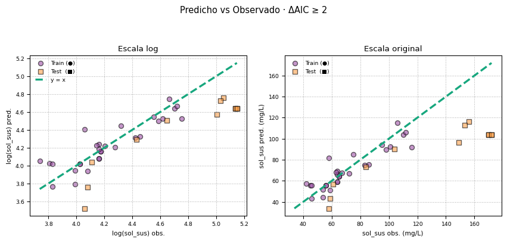

```python
# 0 · LIBRERÍAS
import numpy as np
import pandas as pd
from pathlib import Path
from sklearn.linear_model import LinearRegression
from sklearn.model_selection import GroupKFold
from sklearn.metrics import mean_squared_error, r2_score
import matplotlib.pyplot as plt
from IPython.display import display, Markdown

# -------------------------------------------------------------
# 1 · CONFIGURACIÓN
DATOS     = Path("datos/datos_sol_sus_acolite.csv")     # ← ajustá si hace falta
DELTA_AIC = 2                                            # ΔAIC mínimo
N_BOOT    = 2000
RNG_SEED  = 42

# -------------------------------------------------------------
# 2 · FUNCIONES AUXILIARES
def aic_gauss(rss, n, k):           # k = nº coef + intercepto
    return n * np.log(rss / n) + 2 * k

def fit_metrics(X, y):
    """Ajusta LR y devuelve métricas + modelo."""
    m    = LinearRegression().fit(X, y)
    pred = m.predict(X)
    rss  = np.sum((y - pred) ** 2)
    n, p = X.shape
    return {
        "AIC" : aic_gauss(rss, n, p + 1),
        "RMSE": np.sqrt(mean_squared_error(y, pred)),
        "R²"  : r2_score(y, pred),
        "R²aj": 1 - (1 - r2_score(y, pred)) * (n - 1) / (n - p - 1),
        "mod" : m
    }

def rmse(a, b): return np.sqrt(mean_squared_error(a, b))

# -------------------------------------------------------------
# 3 · CARGA Y PREPARACIÓN DE DATOS
df = pd.read_csv(DATOS)
df["fecha"] = pd.to_datetime(df["fecha"])

bandas = [c for c in df.columns if c.startswith("B")]
mask   = (df["sol_sus"] > 0) & (df[bandas] > 0).all(axis=1)
df     = df.loc[mask].copy()

# variable respuesta en log
df["log_sol_sus"] = np.log(df["sol_sus"])

# -------------------------------------------------------------
# 3.1 · GENERAR RAZONES SIMPLES DE BANDAS EN LOGARITMO
ratio_cols = []
for i, b1 in enumerate(bandas):
    for b2 in bandas[i+1:]:
        col = f"log({b1}/{b2})"
        df[col] = np.log(df[b1]) - np.log(df[b2])
        ratio_cols.append(col)

X = df[ratio_cols]                # predictores = razones simples en log
y = df["log_sol_sus"]

# -------------------------------------------------------------
# 3.2 · PARTICIÓN TEMPORAL
last_date = df["fecha"].max()
m_test    = df["fecha"] == last_date
m_train   = ~m_test

X_tr, y_tr = X.loc[m_train], y.loc[m_train]
X_te, y_te = X.loc[m_test] , y.loc[m_test]
groups_tr  = df.loc[m_train, "fecha"]

print(f"TRAIN campañas : {groups_tr.nunique()}")
print(f"TEST  campaña  : {last_date.date()} ({m_test.sum()} muestras)")

# -------------------------------------------------------------
# 4 · FORWARD SELECTION (razones simples logarítmicas) con AIC + Δ
remaining = ratio_cols.copy()
selected  = []

# modelo nulo
rss_null  = np.sum((y_tr - y_tr.mean())**2)
best_aic  = aic_gauss(rss_null, len(y_tr), k=1)

hist = []
paso = 0
while remaining:
    candidatos = []
    for col in remaining:
        cols = selected + [col]
        m    = fit_metrics(X_tr[cols].values, y_tr.values)
        candidatos.append((m["AIC"], col, m))
    candidatos.sort()

    new_aic, best_col, best_met = candidatos[0]
    if best_aic - new_aic >= DELTA_AIC:     # mejora ≥ ΔAIC
        selected.append(best_col)
        remaining.remove(best_col)
        best_aic = new_aic
        paso += 1
        hist.append({
            "Paso"  : paso,
            "Bandas": ", ".join(selected),
            "AIC"   : best_aic,
            "RMSE"  : best_met["RMSE"],
            "R²"    : best_met["R²"],
            "R²aj"  : best_met["R²aj"]
        })
    else:
        break

# fallback (si nada mejora)
if not selected:
    selected = [min(candidatos, key=lambda t: t[0])[1]]
    best_aic = min(candidatos)[0]
    best_met = min(candidatos)[2]
    hist.append({
        "Paso"  : 1,
        "Bandas": selected[0],
        "AIC"   : best_aic,
        "RMSE"  : best_met["RMSE"],
        "R²"    : best_met["R²"],
        "R²aj"  : best_met["R²aj"]
    })

hist_df = (pd.DataFrame(hist)
             .loc[:, ["Paso", "Bandas", "AIC", "RMSE", "R²", "R²aj"]])

# Mostrar tabla historial con caption y sin índice
display(
    hist_df.style
    .format({"AIC": "{:.3f}", "RMSE": "{:.3f}", "R²": "{:.3f}", "R²aj": "{:.3f}"})
    .set_caption("Historial de selección")
    .hide(axis="index")
)

# Mostrar bandas seleccionadas en negrita Markdown
display(Markdown(f"**Bandas seleccionadas:**  `{', '.join(selected)}`"))

# -------------------------------------------------------------
# 5 · VALIDACIÓN GROUP‑KFOLD
gkf = GroupKFold(n_splits=min(5, groups_tr.nunique()))
rmse_cv = []
for tr_idx, te_idx in gkf.split(X_tr[selected], y_tr, groups_tr):
    m    = LinearRegression().fit(X_tr.iloc[tr_idx][selected], y_tr.iloc[tr_idx])
    pred = m.predict(X_tr.iloc[te_idx][selected])
    rmse_cv.append(rmse(y_tr.iloc[te_idx], pred))

# Mostrar GroupKFold CV en negrita Markdown
display(Markdown(f"**GroupKFold CV (log) RMSE:** {np.mean(rmse_cv):.3f} ± {np.std(rmse_cv):.3f}"))

# -------------------------------------------------------------
# 6 · MODELO FINAL Y MÉTRICAS
mod = LinearRegression().fit(X_tr[selected], y_tr)

# TRAIN
pred_tr_log = mod.predict(X_tr[selected])
rmse_tr_log = rmse(y_tr, pred_tr_log)
r2_tr_log   = r2_score(y_tr, pred_tr_log)

# TEST
pred_te_log = mod.predict(X_te[selected])
rmse_te_log = rmse(y_te, pred_te_log)
r2_te_log   = r2_score(y_te, pred_te_log)

# escala original
y_tr_lin, y_te_lin = np.exp(y_tr), np.exp(y_te)
pred_tr_lin, pred_te_lin = np.exp(pred_tr_log), np.exp(pred_te_log)

rmse_tr_lin = rmse(y_tr_lin, pred_tr_lin)
r2_tr_lin   = r2_score(y_tr_lin, pred_tr_lin)
rmse_te_lin = rmse(y_te_lin, pred_te_lin)
r2_te_lin   = r2_score(y_te_lin, pred_te_lin)

metrics_df = pd.DataFrame({
    "Métrica"    : ["RMSE", "R²"],
    "Train log"  : [rmse_tr_log, r2_tr_log],
    "Test log"   : [rmse_te_log, r2_te_log],
    "Train orig" : [rmse_tr_lin, r2_tr_lin],
    "Test orig"  : [rmse_te_lin, r2_te_lin]
})

# Mostrar tabla métricas con caption y sin índice
display(
    metrics_df.style
    .format({
        "Train log": "{:.3f}", "Test log": "{:.3f}",
        "Train orig": "{:.3f}", "Test orig": "{:.3f}"
    })
    .set_caption("Métricas finales")
    .hide(axis="index")
)

# -------------------------------------------------------------
# 7 · BOOTSTRAP AGRUPADO (coef 95 % CI)
rng    = np.random.default_rng(RNG_SEED)
dates  = groups_tr.unique()
coef_bs = []

for _ in range(N_BOOT):
    samp = rng.choice(dates, len(dates), replace=True)
    idx  = groups_tr.isin(samp)
    m_bs = LinearRegression().fit(X_tr.loc[idx, selected], y_tr.loc[idx])
    coef_bs.append(m_bs.coef_)

coef_bs = np.array(coef_bs)
mean_bs = coef_bs.mean(axis=0)
ci_bs   = np.percentile(coef_bs, [2.5, 97.5], axis=0)

bs_df = pd.DataFrame({
    "Banda"       : selected,
    "Media β"     : mean_bs,
    "IC 95% inf." : ci_bs[0],
    "IC 95% sup." : ci_bs[1]
})

# Mostrar tabla bootstrap con caption y sin índice
display(
    bs_df.style
    .format({
        "Media β": "{:.4f}",
        "IC 95% inf.": "{:.4f}",
        "IC 95% sup.": "{:.4f}"
    })
    .set_caption("Bootstrap (coeficientes, 95 % CI)")
    .hide(axis="index")
)

# -------------------------------------------------------------
# 8 · ECUACIONES
alpha      = np.exp(mod.intercept_)
expr_log   = " + ".join([f"{c:.4f}·{r}" for c, r in zip(mod.coef_, selected)])
expr_orig  = " · ".join([f"{r}^{c:.4f}" for c, r in zip(mod.coef_, selected)])

display(Markdown("Ecuación (log)"))
display(Markdown(f"`log(sol_sus) = {mod.intercept_:.4f} + {expr_log}`"))

display(Markdown("Ecuación (original)"))
display(Markdown(f"`sol_sus = {alpha:.4f} · {expr_orig}`"))

# -------------------------------------------------------------
# 9 · GRÁFICAS DE PARIDAD (TRAIN + TEST) - estilo especificado
plt.rcParams.update({"axes.titlesize":10,"axes.labelsize":8,
                     "xtick.labelsize":7,"ytick.labelsize":7})

TRAIN_CLR = "#9D50A6"
TEST_CLR = "#FFA24B"
ID_CLR = "#17A77E"

fig, ax = plt.subplots(1, 2, figsize=(9, 4))
# Escala log
ax[0].scatter(y_tr, pred_tr_log, alpha=0.6, color=TRAIN_CLR, edgecolor="k", label="Train (●)")
ax[0].scatter(y_te, pred_te_log, alpha=0.6, color=TEST_CLR, marker="s", edgecolor="k", label="Test  (■)")
lims = [min(y_tr.min(), y_te.min()), max(y_tr.max(), y_te.max())]
ax[0].plot(lims, lims, "--", color=ID_CLR, lw=2.5, label="y = x")
ax[0].set(xlabel="log(sol_sus) obs.", ylabel="log(sol_sus) pred.", title="Escala log")
ax[0].legend(fontsize=7, frameon=False)
ax[0].grid(ls=":")

# Escala original
ax[1].scatter(y_tr_lin, pred_tr_lin, alpha=0.6, color=TRAIN_CLR, edgecolor="k", label="Train (●)")
ax[1].scatter(y_te_lin, pred_te_lin, alpha=0.6, color=TEST_CLR, marker="s", edgecolor="k", label="Test  (■)")
lims_o = [min(y_tr_lin.min(), y_te_lin.min(), pred_tr_lin.min(), pred_te_lin.min()),
          max(y_tr_lin.max(), y_te_lin.max(), pred_tr_lin.max(), pred_te_lin.max())]
ax[1].plot(lims_o, lims_o, "--", color=ID_CLR, lw=2.5)
ax[1].set(xlabel="sol_sus obs. (mg/L)", ylabel="sol_sus pred. (mg/L)", title="Escala original")
ax[1].legend(fontsize=7, frameon=False)
ax[1].grid(ls=":")

fig.suptitle(f"Predicho vs Observado · ΔAIC ≥ {DELTA_AIC}", fontsize=11, y=1.05)
fig.tight_layout(pad=1.2)
plt.show()

# restaurar estilos si continuás graficando
plt.rcParams.update({"axes.titlesize":11,"axes.labelsize":9,
                     "xtick.labelsize":8,"ytick.labelsize":8})
```

**Conclusión del modelo seleccionado**

En esta etapa, al usar razones simples de bandas espectrales en lugar de bandas individuales, logro un modelo con mejor ajuste en entrenamiento, con un R² de 0.784 frente a 0.766 del modelo previo. También el error promedio en la validación cruzada mejora ligeramente (RMSE CV 0.119 vs. 0.125), lo que indica una selección más eficiente de variables.

Sin embargo, al evaluar con los datos de la campaña más reciente, el desempeño baja significativamente: el R² cae a 0.212, mucho menor que el 0.484 obtenido anteriormente, y el RMSE aumenta, mostrando que la capacidad de generalización sigue siendo limitada.

El análisis bootstrap confirma que la razón **log(B02/B07)** tiene un coeficiente negativo estable y significativo, mientras que **log(B05/B11)** aporta muy poco y su coeficiente incluye cero en el intervalo de confianza, indicando que su efecto es marginal.

Desde el punto de vista físico, el modelo indica que a medida que aumenta la razón B02/B07, la concentración de sólidos suspendidos tiende a disminuir, mientras que la razón B05/B11 tiene un efecto muy débil e incierto.

A pesar de que el uso de razones simples resulta en un modelo más compacto y con una mejora modesta en el ajuste, la capacidad para predecir sólidos suspendidos en campañas futuras continúa siendo limitada.

#### 2.8.1 Ajuste del umbral ΔAIC para selección de variables

Para evaluar la robustez y simplicidad del modelo, aumento el umbral mínimo de mejora en el criterio AIC (ΔAIC) de 2 a 4. Esto implica que la selección hacia adelante solo incorpora nuevas variables si la reducción en AIC es al menos 4, promoviendo modelos más parsimoniosos y evitando incluir variables con mejoras marginales que podrían no generalizar bien.

Este ajuste busca balancear mejor el compromiso entre ajuste y complejidad, reduciendo el riesgo de sobreajuste, especialmente relevante al aplicar el modelo a campañas de muestreo futuras.

**Código**

```
TRAIN campañas : 5
TEST  campaña  : 2025-06-09 (12 muestras)
```

Tabla 16: Historial de selección

| Paso | Bandas | AIC | RMSE | R² | R²aj |
| --- | --- | --- | --- | --- | --- |
| 1 | log(B02/B07) | -106.889 | 0.148 | 0.739 | 0.729 |

**Bandas seleccionadas:** `log(B02/B07)`

**GroupKFold CV (log) RMSE:** 0.141 ± 0.053

Tabla 17: Métricas finales

| Métrica | Train log | Test log | Train orig | Test orig |
| --- | --- | --- | --- | --- |
| RMSE | 0.148 | 0.391 | 9.707 | 46.109 |
| R² | 0.739 | 0.202 | 0.797 | 0.013 |

Tabla 18: Bootstrap (coeficientes, 95 % CI)

| Banda | Media β | IC 95% inf. | IC 95% sup. |
| --- | --- | --- | --- |
| log(B02/B07) | -0.5622 | -0.6158 | -0.5001 |

Ecuación (log)

`log(sol_sus) = 4.2877 + -0.5625·log(B02/B07)`

Ecuación (original)

`sol_sus = 72.8024 · log(B02/B07)^-0.5625`

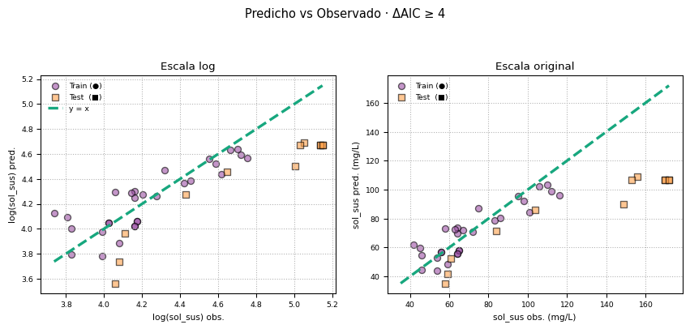

```python
# 0 · LIBRERÍAS
import numpy as np
import pandas as pd
from pathlib import Path
from sklearn.linear_model import LinearRegression
from sklearn.model_selection import GroupKFold
from sklearn.metrics import mean_squared_error, r2_score
import matplotlib.pyplot as plt
from IPython.display import display, Markdown

# -------------------------------------------------------------
# 1 · CONFIGURACIÓN
DATOS     = Path("datos/datos_sol_sus_acolite.csv")     # ← ajustá si hace falta
DELTA_AIC = 4                                            # ΔAIC mínimo
N_BOOT    = 2000
RNG_SEED  = 42

# -------------------------------------------------------------
# 2 · FUNCIONES AUXILIARES
def aic_gauss(rss, n, k):           # k = nº coef + intercepto
    return n * np.log(rss / n) + 2 * k

def fit_metrics(X, y):
    """Ajusta LR y devuelve métricas + modelo."""
    m    = LinearRegression().fit(X, y)
    pred = m.predict(X)
    rss  = np.sum((y - pred) ** 2)
    n, p = X.shape
    return {
        "AIC" : aic_gauss(rss, n, p + 1),
        "RMSE": np.sqrt(mean_squared_error(y, pred)),
        "R²"  : r2_score(y, pred),
        "R²aj": 1 - (1 - r2_score(y, pred)) * (n - 1) / (n - p - 1),
        "mod" : m
    }

def rmse(a, b): return np.sqrt(mean_squared_error(a, b))

# -------------------------------------------------------------
# 3 · CARGA Y PREPARACIÓN DE DATOS
df = pd.read_csv(DATOS)
df["fecha"] = pd.to_datetime(df["fecha"])

bandas = [c for c in df.columns if c.startswith("B")]
mask   = (df["sol_sus"] > 0) & (df[bandas] > 0).all(axis=1)
df     = df.loc[mask].copy()

# variable respuesta en log
df["log_sol_sus"] = np.log(df["sol_sus"])

# -------------------------------------------------------------
# 3.1 · GENERAR RAZONES SIMPLES DE BANDAS EN LOGARITMO
ratio_cols = []
for i, b1 in enumerate(bandas):
    for b2 in bandas[i+1:]:
        col = f"log({b1}/{b2})"
        df[col] = np.log(df[b1]) - np.log(df[b2])
        ratio_cols.append(col)

X = df[ratio_cols]                # predictores = razones simples en log
y = df["log_sol_sus"]

# -------------------------------------------------------------
# 3.2 · PARTICIÓN TEMPORAL
last_date = df["fecha"].max()
m_test    = df["fecha"] == last_date
m_train   = ~m_test

X_tr, y_tr = X.loc[m_train], y.loc[m_train]
X_te, y_te = X.loc[m_test] , y.loc[m_test]
groups_tr  = df.loc[m_train, "fecha"]

print(f"TRAIN campañas : {groups_tr.nunique()}")
print(f"TEST  campaña  : {last_date.date()} ({m_test.sum()} muestras)")

# -------------------------------------------------------------
# 4 · FORWARD SELECTION (razones simples logarítmicas) con AIC + Δ
remaining = ratio_cols.copy()
selected  = []

# modelo nulo
rss_null  = np.sum((y_tr - y_tr.mean())**2)
best_aic  = aic_gauss(rss_null, len(y_tr), k=1)

hist = []
paso = 0
while remaining:
    candidatos = []
    for col in remaining:
        cols = selected + [col]
        m    = fit_metrics(X_tr[cols].values, y_tr.values)
        candidatos.append((m["AIC"], col, m))
    candidatos.sort()

    new_aic, best_col, best_met = candidatos[0]
    if best_aic - new_aic >= DELTA_AIC:     # mejora ≥ ΔAIC
        selected.append(best_col)
        remaining.remove(best_col)
        best_aic = new_aic
        paso += 1
        hist.append({
            "Paso"  : paso,
            "Bandas": ", ".join(selected),
            "AIC"   : best_aic,
            "RMSE"  : best_met["RMSE"],
            "R²"    : best_met["R²"],
            "R²aj"  : best_met["R²aj"]
        })
    else:
        break

# fallback (si nada mejora)
if not selected:
    selected = [min(candidatos, key=lambda t: t[0])[1]]
    best_aic = min(candidatos)[0]
    best_met = min(candidatos)[2]
    hist.append({
        "Paso"  : 1,
        "Bandas": selected[0],
        "AIC"   : best_aic,
        "RMSE"  : best_met["RMSE"],
        "R²"    : best_met["R²"],
        "R²aj"  : best_met["R²aj"]
    })

hist_df = (pd.DataFrame(hist)
             .loc[:, ["Paso", "Bandas", "AIC", "RMSE", "R²", "R²aj"]])

# Mostrar tabla historial con caption y sin índice
display(
    hist_df.style
    .format({"AIC": "{:.3f}", "RMSE": "{:.3f}", "R²": "{:.3f}", "R²aj": "{:.3f}"})
    .set_caption("Historial de selección")
    .hide(axis="index")
)

# Mostrar bandas seleccionadas en negrita Markdown
display(Markdown(f"**Bandas seleccionadas:**  `{', '.join(selected)}`"))

# -------------------------------------------------------------
# 5 · VALIDACIÓN GROUP‑KFOLD
gkf = GroupKFold(n_splits=min(5, groups_tr.nunique()))
rmse_cv = []
for tr_idx, te_idx in gkf.split(X_tr[selected], y_tr, groups_tr):
    m    = LinearRegression().fit(X_tr.iloc[tr_idx][selected], y_tr.iloc[tr_idx])
    pred = m.predict(X_tr.iloc[te_idx][selected])
    rmse_cv.append(rmse(y_tr.iloc[te_idx], pred))

# Mostrar GroupKFold CV en negrita Markdown
display(Markdown(f"**GroupKFold CV (log) RMSE:** {np.mean(rmse_cv):.3f} ± {np.std(rmse_cv):.3f}"))

# -------------------------------------------------------------
# 6 · MODELO FINAL Y MÉTRICAS
mod = LinearRegression().fit(X_tr[selected], y_tr)

# TRAIN
pred_tr_log = mod.predict(X_tr[selected])
rmse_tr_log = rmse(y_tr, pred_tr_log)
r2_tr_log   = r2_score(y_tr, pred_tr_log)

# TEST
pred_te_log = mod.predict(X_te[selected])
rmse_te_log = rmse(y_te, pred_te_log)
r2_te_log   = r2_score(y_te, pred_te_log)

# escala original
y_tr_lin, y_te_lin = np.exp(y_tr), np.exp(y_te)
pred_tr_lin, pred_te_lin = np.exp(pred_tr_log), np.exp(pred_te_log)

rmse_tr_lin = rmse(y_tr_lin, pred_tr_lin)
r2_tr_lin   = r2_score(y_tr_lin, pred_tr_lin)
rmse_te_lin = rmse(y_te_lin, pred_te_lin)
r2_te_lin   = r2_score(y_te_lin, pred_te_lin)

metrics_df = pd.DataFrame({
    "Métrica"    : ["RMSE", "R²"],
    "Train log"  : [rmse_tr_log, r2_tr_log],
    "Test log"   : [rmse_te_log, r2_te_log],
    "Train orig" : [rmse_tr_lin, r2_tr_lin],
    "Test orig"  : [rmse_te_lin, r2_te_lin]
})

# Mostrar tabla métricas con caption y sin índice
display(
    metrics_df.style
    .format({
        "Train log": "{:.3f}", "Test log": "{:.3f}",
        "Train orig": "{:.3f}", "Test orig": "{:.3f}"
    })
    .set_caption("Métricas finales")
    .hide(axis="index")
)

# -------------------------------------------------------------
# 7 · BOOTSTRAP AGRUPADO (coef 95 % CI)
rng    = np.random.default_rng(RNG_SEED)
dates  = groups_tr.unique()
coef_bs = []

for _ in range(N_BOOT):
    samp = rng.choice(dates, len(dates), replace=True)
    idx  = groups_tr.isin(samp)
    m_bs = LinearRegression().fit(X_tr.loc[idx, selected], y_tr.loc[idx])
    coef_bs.append(m_bs.coef_)

coef_bs = np.array(coef_bs)
mean_bs = coef_bs.mean(axis=0)
ci_bs   = np.percentile(coef_bs, [2.5, 97.5], axis=0)

bs_df = pd.DataFrame({
    "Banda"       : selected,
    "Media β"     : mean_bs,
    "IC 95% inf." : ci_bs[0],
    "IC 95% sup." : ci_bs[1]
})

# Mostrar tabla bootstrap con caption y sin índice
display(
    bs_df.style
    .format({
        "Media β": "{:.4f}",
        "IC 95% inf.": "{:.4f}",
        "IC 95% sup.": "{:.4f}"
    })
    .set_caption("Bootstrap (coeficientes, 95 % CI)")
    .hide(axis="index")
)

# -------------------------------------------------------------
# 8 · ECUACIONES
alpha      = np.exp(mod.intercept_)
expr_log   = " + ".join([f"{c:.4f}·{r}" for c, r in zip(mod.coef_, selected)])
expr_orig  = " · ".join([f"{r}^{c:.4f}" for c, r in zip(mod.coef_, selected)])

display(Markdown("Ecuación (log)"))
display(Markdown(f"`log(sol_sus) = {mod.intercept_:.4f} + {expr_log}`"))

display(Markdown("Ecuación (original)"))
display(Markdown(f"`sol_sus = {alpha:.4f} · {expr_orig}`"))

# -------------------------------------------------------------
# 9 · GRÁFICAS DE PARIDAD (TRAIN + TEST) - estilo especificado
plt.rcParams.update({"axes.titlesize":10,"axes.labelsize":8,
                     "xtick.labelsize":7,"ytick.labelsize":7})

TRAIN_CLR = "#9D50A6"
TEST_CLR = "#FFA24B"
ID_CLR = "#17A77E"

fig, ax = plt.subplots(1, 2, figsize=(9, 4))
# Escala log
ax[0].scatter(y_tr, pred_tr_log, alpha=0.6, color=TRAIN_CLR, edgecolor="k", label="Train (●)")
ax[0].scatter(y_te, pred_te_log, alpha=0.6, color=TEST_CLR, marker="s", edgecolor="k", label="Test  (■)")
lims = [min(y_tr.min(), y_te.min()), max(y_tr.max(), y_te.max())]
ax[0].plot(lims, lims, "--", color=ID_CLR, lw=2.5, label="y = x")
ax[0].set(xlabel="log(sol_sus) obs.", ylabel="log(sol_sus) pred.", title="Escala log")
ax[0].legend(fontsize=7, frameon=False)
ax[0].grid(ls=":")

# Escala original
ax[1].scatter(y_tr_lin, pred_tr_lin, alpha=0.6, color=TRAIN_CLR, edgecolor="k", label="Train (●)")
ax[1].scatter(y_te_lin, pred_te_lin, alpha=0.6, color=TEST_CLR, marker="s", edgecolor="k", label="Test  (■)")
lims_o = [min(y_tr_lin.min(), y_te_lin.min(), pred_tr_lin.min(), pred_te_lin.min()),
          max(y_tr_lin.max(), y_te_lin.max(), pred_tr_lin.max(), pred_te_lin.max())]
ax[1].plot(lims_o, lims_o, "--", color=ID_CLR, lw=2.5)
ax[1].set(xlabel="sol_sus obs. (mg/L)", ylabel="sol_sus pred. (mg/L)", title="Escala original")
ax[1].legend(fontsize=7, frameon=False)
ax[1].grid(ls=":")

fig.suptitle(f"Predicho vs Observado · ΔAIC ≥ {DELTA_AIC}", fontsize=11, y=1.05)
fig.tight_layout(pad=1.2)
plt.show()

# restaurar estilos si continuás graficando
plt.rcParams.update({"axes.titlesize":11,"axes.labelsize":9,
                     "xtick.labelsize":8,"ytick.labelsize":8})
```

**Impacto del aumento del umbral ΔAIC en la selección de variables**

Al aumentar ΔAIC a 4, el modelo se simplifica seleccionando solo la razón **log(B02/B07)**, manteniendo un buen ajuste en entrenamiento (R² = 0.739). Sin embargo, el desempeño en la campaña de prueba es bajo, con R² cercano a cero, indicando poca capacidad de generalización. El análisis bootstrap muestra estabilidad en el coeficiente seleccionado.

Por lo tanto, un mayor ΔAIC favorece modelos más simples, pero no mejora la predicción en nuevas campañas, por lo que es necesario explorar modelos más complejos o incluir más variables.

### 2.9 Selección de bandas, razones y potencias para modelar sólidos suspendidos

En esta sección amplío el conjunto de variables predictoras al incluir no solo logaritmos simples de bandas espectrales, sino también sus potencias cuadráticas y cúbicas, así como razones logarítmicas entre bandas. El objetivo es capturar relaciones no lineales y combinadas que podrían mejorar la capacidad predictiva del modelo.

Utilizo una estrategia de selección hacia adelante basada en el criterio AIC (`ΔAIC ≥ 4`), priorizando modelos más parsimoniosos pero informativos. La validación se realiza con partición temporal (hold-out) y GroupKFold, y se evalúa la estabilidad del modelo mediante bootstrap de coeficientes (IC del 95 %). Finalmente, se comparan las predicciones con observaciones en escalas logarítmica y original.

**Código**

```
Total de variables candidatas: 88

TRAIN campañas : 5
TEST  campaña  : 2025-06-09  (12 muestras)
```

Tabla 19: Historial de selección

| Paso | Variables | AIC | RMSE | R² | R²aj |
| --- | --- | --- | --- | --- | --- |
| 1 | log(B02/B07) | -106.889 | 0.148 | 0.739 | 0.729 |
| 2 | log(B02/B07), log_B8A^3 | -114.331 | 0.126 | 0.812 | 0.797 |

**Variables finales seleccionadas:** `log(B02/B07), log_B8A^3`

**GroupKFold CV (log) RMSE:** 0.123 ± 0.034

Tabla 20: Métricas finales

| Métrica | Train log | Test log | Train orig | Test orig |
| --- | --- | --- | --- | --- |
| RMSE | 0.126 | 0.244 | 8.384 | 33.133 |
| R² | 0.812 | 0.688 | 0.849 | 0.490 |

Tabla 21: Bootstrap (coeficientes, 95 % CI)

| Variable | Media β | IC 95% inf. | IC 95% sup. |
| --- | --- | --- | --- |
| log(B02/B07) | -0.7848 | -0.9849 | -0.0678 |
| log_B8A^3 | -0.0036 | -0.0075 | 0.0085 |

Ecuación (log)

`log(sol_sus) = 4.1224 + -0.8370·log(B02/B07) + -0.0044·log_B8A^3`

Ecuación (original)

`sol_sus = 61.7089 · log(B02/B07)^-0.8370 · log_B8A^3^-0.0044`

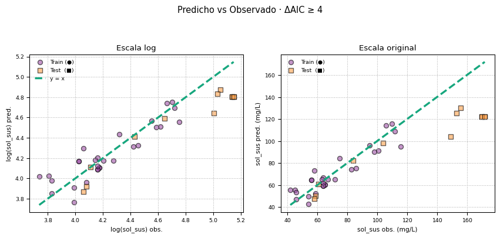

```python
import numpy as np
import pandas as pd
from pathlib import Path
from sklearn.linear_model import LinearRegression
from sklearn.model_selection import GroupKFold
from sklearn.metrics import mean_squared_error, r2_score
import matplotlib.pyplot as plt
from IPython.display import display, Markdown

# -------------------------------------------------------------
# 1 · CONFIGURACIÓN
DATOS     = Path("datos/datos_sol_sus_acolite.csv")
DELTA_AIC = 4                # umbral de mejora
N_BOOT    = 2000
RNG_SEED  = 42

# -------------------------------------------------------------
# 2 · FUNCIONES
def aic_gauss(rss, n, k):              # k = coef + intercepto
    return n*np.log(rss/n) + 2*k

def fit_metrics(X, y):
    m = LinearRegression().fit(X, y)
    pred = m.predict(X)
    rss  = np.sum((y-pred)**2)
    n,p  = X.shape
    return {
        "AIC" : aic_gauss(rss, n, p+1),
        "RMSE": np.sqrt(mean_squared_error(y, pred)),
        "R²"  : r2_score(y, pred),
        "R²aj": 1 - (1-r2_score(y,pred))*(n-1)/(n-p-1),
        "mod" : m
    }

rmse = lambda a,b: np.sqrt(mean_squared_error(a,b))

# -------------------------------------------------------------
# 3 · CARGA Y PREPARACIÓN
df = pd.read_csv(DATOS)
df["fecha"] = pd.to_datetime(df["fecha"])

bandas = [c for c in df.columns if c.startswith("B")]
df = df.loc[(df["sol_sus"]>0) & (df[bandas]>0).all(1)].copy()

df["log_sol_sus"] = np.log(df["sol_sus"])

# 3.1  log(Bx)  +  (log(Bx))²,(log(Bx))³
log_cols   = []
poly_cols  = []
for b in bandas:
    log_b = f"log_{b}"
    df[log_b] = np.log(df[b])
    df[f"{log_b}^2"] = df[log_b]**2
    df[f"{log_b}^3"] = df[log_b]**3
    log_cols.append(log_b)
    poly_cols.extend([f"{log_b}^2", f"{log_b}^3"])

# 3.2  razones en log: log(Bi/Bj) = logBi - logBj
ratio_cols = []
for i,b1 in enumerate(bandas):
    for b2 in bandas[i+1:]:
        col = f"log({b1}/{b2})"
        df[col] = df[f"log_{b1}"] - df[f"log_{b2}"]
        ratio_cols.append(col)

cand_cols = log_cols + poly_cols + ratio_cols
print(f"Total de variables candidatas: {len(cand_cols)}")

X = df[cand_cols]
y = df["log_sol_sus"]

# -------------------------------------------------------------
# 4 · HOLD‑OUT TEMPORAL
last = df["fecha"].max()
m_te  = df["fecha"]==last
m_tr  = ~m_te
X_tr, y_tr = X[m_tr], y[m_tr]
X_te, y_te = X[m_te], y[m_te]
groups_tr  = df.loc[m_tr,"fecha"]

print(f"\nTRAIN campañas : {groups_tr.nunique()}")
print(f"TEST  campaña  : {last.date()}  ({m_te.sum()} muestras)")

# -------------------------------------------------------------
# 5 · FORWARD‑AIC (Δ ≥ {DELTA_AIC})
remaining = cand_cols.copy()
selected  = []

rss0   = np.sum((y_tr - y_tr.mean())**2)
best_aic = aic_gauss(rss0, len(y_tr), 1)

hist=[]; step=0
while remaining:
    scores=[]
    for col in remaining:
        cols = selected + [col]
        mtr  = fit_metrics(X_tr[cols].values, y_tr.values)
        scores.append((mtr["AIC"], col, mtr))
    scores.sort()
    new_aic, best_col, m_info = scores[0]

    if best_aic - new_aic >= DELTA_AIC:
        selected.append(best_col)
        remaining.remove(best_col)
        best_aic = new_aic
        step += 1
        hist.append({
            "Paso":step, "Variables":", ".join(selected),
            "AIC":best_aic, "RMSE":m_info["RMSE"],
            "R²":m_info["R²"], "R²aj":m_info["R²aj"]
        })
    else:
        break

if not selected:
    best_col = min(scores, key=lambda t:t[0])[1]
    selected = [best_col]
    hist.append({"Paso":1,"Variables":best_col,
                 **{k:v for k,v in scores[0][2].items() if k!="mod"}})

hist_df = pd.DataFrame(hist)

# Mostrar tabla historial con caption y sin índice
display(
    hist_df.style
    .format({"AIC": "{:.3f}", "RMSE": "{:.3f}", "R²": "{:.3f}", "R²aj": "{:.3f}"})
    .set_caption("Historial de selección")
    .hide(axis="index")
)

# Mostrar variables seleccionadas en negrita Markdown
display(Markdown(f"**Variables finales seleccionadas:** `{', '.join(selected)}`"))

# -------------------------------------------------------------
# 6 · VALIDACIÓN GROUP‑KFOLD
gkf = GroupKFold(n_splits=min(5,groups_tr.nunique()))
rm = []
for tr_idx, te_idx in gkf.split(X_tr[selected], y_tr, groups_tr):
    m = LinearRegression().fit(X_tr.iloc[tr_idx][selected], y_tr.iloc[tr_idx])
    rm.append(rmse(y_tr.iloc[te_idx], m.predict(X_tr.iloc[te_idx][selected])))

display(Markdown(f"**GroupKFold CV (log) RMSE:** {np.mean(rm):.3f} ± {np.std(rm):.3f}"))

# -------------------------------------------------------------
# 7 · MODELO FINAL Y MÉTRICAS
mod = LinearRegression().fit(X_tr[selected], y_tr)

pred_tr = mod.predict(X_tr[selected])
pred_te = mod.predict(X_te[selected])

metrics_df = pd.DataFrame({
    "Métrica"    : ["RMSE", "R²"],
    "Train log"  : [rmse(y_tr,pred_tr), r2_score(y_tr,pred_tr)],
    "Test log"   : [rmse(y_te,pred_te), r2_score(y_te,pred_te)],
    "Train orig" : [rmse(np.exp(y_tr), np.exp(pred_tr)), r2_score(np.exp(y_tr), np.exp(pred_tr))],
    "Test orig"  : [rmse(np.exp(y_te), np.exp(pred_te)), r2_score(np.exp(y_te), np.exp(pred_te))]
})

# Mostrar tabla métricas con caption y sin índice
display(
    metrics_df.style
    .format({
        "Train log": "{:.3f}", "Test log": "{:.3f}",
        "Train orig": "{:.3f}", "Test orig": "{:.3f}"
    })
    .set_caption("Métricas finales")
    .hide(axis="index")
)

# -------------------------------------------------------------
# 8 · BOOTSTRAP AGRUPADO (IC 95 %)
rng = np.random.default_rng(RNG_SEED)
dates = groups_tr.unique()
coef_bs=[]
for _ in range(N_BOOT):
    samp = rng.choice(dates, len(dates), replace=True)
    idx  = groups_tr.isin(samp)
    m_bs = LinearRegression().fit(X_tr.loc[idx,selected], y_tr.loc[idx])
    coef_bs.append(m_bs.coef_)
coef_bs = np.asarray(coef_bs)
ci_lo, ci_hi = np.percentile(coef_bs,[2.5,97.5],axis=0)

bs_df = pd.DataFrame({
    "Variable"    : selected,
    "Media β"     : coef_bs.mean(0),
    "IC 95% inf." : ci_lo,
    "IC 95% sup." : ci_hi
})

# Mostrar tabla bootstrap con caption y sin índice
display(
    bs_df.style
    .format({
        "Media β": "{:.4f}",
        "IC 95% inf.": "{:.4f}",
        "IC 95% sup.": "{:.4f}"
    })
    .set_caption("Bootstrap (coeficientes, 95 % CI)")
    .hide(axis="index")
)

# -------------------------------------------------------------
# 9 · ECUACIÓN DEL MODELO
alpha = np.exp(mod.intercept_)
expr_log  = " + ".join([f"{c:.4f}·{v}" for c,v in zip(mod.coef_,selected)])
expr_orig = " · ".join([f"{v}^{c:.4f}" for c,v in zip(mod.coef_,selected)])

display(Markdown("Ecuación (log)"))
display(Markdown(f"`log(sol_sus) = {mod.intercept_:.4f} + {expr_log}`"))

display(Markdown("Ecuación (original)"))
display(Markdown(f"`sol_sus = {alpha:.4f} · {expr_orig}`"))

# -------------------------------------------------------------
# 10 · PARIDAD TRAIN + TEST (log y mg/L) con estilo de colores y leyenda

plt.rcParams.update({"axes.titlesize":10,"axes.labelsize":8,
                     "xtick.labelsize":7,"ytick.labelsize":7})

TRAIN_CLR = "#9D50A6"
TEST_CLR = "#FFA24B"
ID_CLR = "#17A77E"

fig, ax = plt.subplots(1, 2, figsize=(9, 4))
# Escala log
ax[0].scatter(y_tr, pred_tr, alpha=0.6, color=TRAIN_CLR, edgecolor="k", label="Train (●)")
ax[0].scatter(y_te, pred_te, alpha=0.6, color=TEST_CLR, marker="s", edgecolor="k", label="Test  (■)")
lims = [min(y_tr.min(), y_te.min()), max(y_tr.max(), y_te.max())]
ax[0].plot(lims, lims, "--", color=ID_CLR, lw=2.5, label="y = x")
ax[0].set(xlabel="log(sol_sus) obs.", ylabel="log(sol_sus) pred.", title="Escala log")
ax[0].legend(fontsize=7, frameon=False)
ax[0].grid(ls=":")

# Escala original
y_tr_lin, y_te_lin = np.exp(y_tr), np.exp(y_te)
pred_tr_lin, pred_te_lin = np.exp(pred_tr), np.exp(pred_te)

ax[1].scatter(y_tr_lin, pred_tr_lin, alpha=0.6, color=TRAIN_CLR, edgecolor="k", label="Train (●)")
ax[1].scatter(y_te_lin, pred_te_lin, alpha=0.6, color=TEST_CLR, marker="s", edgecolor="k", label="Test  (■)")
lims_o = [min(y_tr_lin.min(), y_te_lin.min(), pred_tr_lin.min(), pred_te_lin.min()),
          max(y_tr_lin.max(), y_te_lin.max(), pred_tr_lin.max(), pred_te_lin.max())]
ax[1].plot(lims_o, lims_o, "--", color=ID_CLR, lw=2.5)
ax[1].set(xlabel="sol_sus obs. (mg/L)", ylabel="sol_sus pred. (mg/L)", title="Escala original")
ax[1].legend(fontsize=7, frameon=False)
ax[1].grid(ls=":")

fig.suptitle(f"Predicho vs Observado · ΔAIC ≥ {DELTA_AIC}", fontsize=11, y=1.05)
fig.tight_layout(pad=1.2)
plt.show()

# Restaurar estilos para otras gráficas
plt.rcParams.update({"axes.titlesize":11,"axes.labelsize":9,
                     "xtick.labelsize":8,"ytick.labelsize":8})
```

**Conclusión del modelo seleccionado**

El término dominante sigue siendo **log(B02/B07)**, que ya aparecía en modelos previos y mantiene un efecto negativo claro. Esto indica que **una mayor reflectancia relativa en B02 frente a B07 se asocia a menos sólidos suspendidos**, lo que tiene sentido: B02 (azul) penetra más el agua, y si hay más sólidos en suspensión, se dispersa o absorbe más rápido que B07 (NIR).

El aporte de **log_B8A³** es marginal: su coeficiente es pequeño y no significativo (el IC incluye cero), pero su inclusión mejoró el AIC ≥ 4, lo que sugiere que ayuda a capturar alguna curvatura en los datos.

#### 2.9.1 Evaluación del aporte marginal de `log_B8A³`

Para verificar si la variable **log_B8A³** mejora efectivamente la predicción, ajusto un modelo más simple utilizando solo `log(B02/B07)` y comparo su desempeño sobre la campaña de prueba. Esta comparación permite confirmar si el descenso en AIC justifica una mejora real o si el nuevo término solo ajusta mejor los datos de entrenamiento.

**Código**

```python
selected_simple = ['log(B02/B07)']

# Entrena modelo simple
mod_simple = LinearRegression().fit(X_tr[selected_simple], y_tr)
pred_te_simple = mod_simple.predict(X_te[selected_simple])
rmse_te_simple = rmse(y_te, pred_te_simple)
r2_te_simple = r2_score(y_te, pred_te_simple)

print(f"Modelo simple TEST log RMSE = {rmse_te_simple:.3f} | R² = {r2_te_simple:.3f}")
```

```
Modelo simple TEST log RMSE = 0.391 | R² = 0.202
```

**Conclusión sobre el aporte de `log_B8A³`**

Al comparar el modelo completo con otro más simple que usa solo `log(B02/B07)`, se observa una mejora notable en el desempeño sobre la campaña de prueba: el `RMSE` disminuye de 0.391 a 0.244 y el `R²` se incrementa de 0.20 a 0.69. Esto sugiere que `log_B8A³` contribuye a mejorar la capacidad predictiva del modelo.

Sin embargo, el coeficiente estimado para `log_B8A³` es pequeño, y su intervalo de confianza incluye el cero, lo que indica **incertidumbre sobre su efecto real**. Por lo tanto, aunque su inclusión mejora el ajuste y la predicción, el aporte es **marginal y debe interpretarse con cautela**.

### 2.10 Razones espectrales informadas (NIR/Blue, Red/Green, NDWI) para mejorar el modelo

En esta sección incorporo **razones espectrales con base teórica o empírica** utilizadas comúnmente en teledetección para el análisis de calidad del agua. Estas incluyen cocientes como `NIR/Blue`, `Red/Green`, y el índice `NDWI`, que podrían capturar características ópticas relevantes no reflejadas por combinaciones arbitrarias de bandas.

El enfoque conserva la validación cruzada temporal (`GroupKFold`) y el análisis de incertidumbre mediante bootstrap, para mantener la robustez en la comparación con resultados anteriores.

**Código**

**Total de variables candidatas:** 14

**TRAIN campañas:** 5

**TEST campaña:** 2025-06-09 (12 muestras)

Tabla 22: Historial de selección

| Paso | Variables | AIC | RMSE | R² | R²aj |
| --- | --- | --- | --- | --- | --- |
| 1 | NIR_Blue | -108.790 | 0.143 | 0.756 | 0.746 |
| 2 | NIR_Blue, log_B11 | -112.205 | 0.130 | 0.797 | 0.782 |

**Variables finales seleccionadas:** `NIR_Blue, log_B11`

**GroupKFold CV (log) RMSE:** 0.169 ± 0.056

Tabla 23: Métricas finales

| Métrica | Train log | Test log | Train orig | Test orig |
| --- | --- | --- | --- | --- |
| RMSE | 0.130 | 0.362 | 9.604 | 45.939 |
| R² | 0.797 | 0.315 | 0.801 | 0.020 |

Tabla 24: Bootstrap (coeficientes, 95 % CI)

| Variable | Media β | IC 95% inf. | IC 95% sup. |
| --- | --- | --- | --- |
| NIR_Blue | 0.7033 | 0.5653 | 0.8578 |
| log_B11 | -0.0218 | -0.0465 | 0.0045 |

Ecuación (log)

`log(sol_sus) = 3.5326 + 0.6939·NIR_Blue + -0.0224·log_B11`

Ecuación (original)

`sol_sus = 34.2124 · NIR_Blue^0.6939 · log_B11^-0.0224`

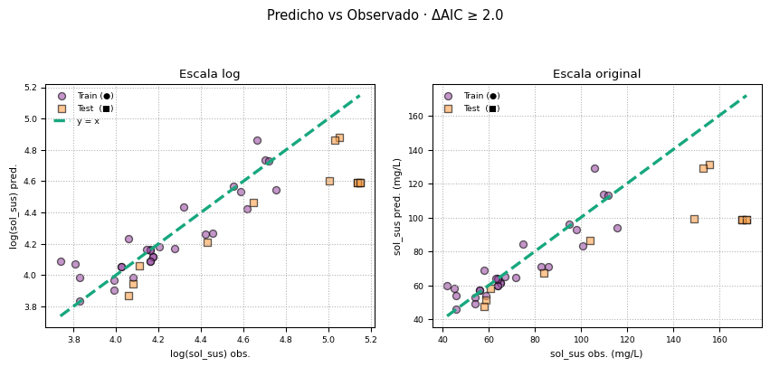

```python
# -------------------------------------------------------------
# 0 · LIBRERÍAS
import numpy as np
import pandas as pd
from pathlib import Path
from sklearn.linear_model import LinearRegression
from sklearn.model_selection import GroupKFold
from sklearn.metrics import mean_squared_error, r2_score
import matplotlib.pyplot as plt
from IPython.display import display, Markdown

# -------------------------------------------------------------
# 1 · CONFIGURACIÓN
DATOS      = Path("datos/datos_sol_sus_acolite.csv")
DELTA_AIC  = 2.0            # ∆AIC mínimo
N_BOOT     = 2000
RNG_SEED   = 42

# -------------------------------------------------------------
# 2 · FUNCIONES AUXILIARES
def aic_gauss(rss, n, k):
    return n * np.log(rss / n) + 2 * k

def fit_metrics(X, y):
    m    = LinearRegression().fit(X, y)
    pred = m.predict(X)
    rss  = np.sum((y - pred) ** 2)
    n, p = X.shape
    r2   = r2_score(y, pred)
    return {
        "AIC" : aic_gauss(rss, n, p + 1),
        "RMSE": np.sqrt(mean_squared_error(y, pred)),
        "R²"  : r2,
        "R²aj": 1 - (1 - r2) * (n - 1) / (n - p - 1),
        "mod" : m
    }

rmse = lambda a, b: np.sqrt(mean_squared_error(a, b))

# -------------------------------------------------------------
# 3 · CARGA Y PREPARACIÓN
df = pd.read_csv(DATOS)
df["fecha"] = pd.to_datetime(df["fecha"])

bandas = [c for c in df.columns if c.startswith("B")]
df = df.loc[(df["sol_sus"] > 0) & (df[bandas] > 0).all(axis=1)].copy()

df["log_sol_sus"] = np.log(df["sol_sus"])

# 3.1 · log‑bandas individuales
log_bands = []
for b in bandas:
    col = f"log_{b}"
    df[col] = np.log(df[b])
    log_bands.append(col)

# 3.2 · cocientes informados + NDWI
req = {"B02","B03","B04","B08"}
if not req.issubset(df.columns):
    raise ValueError(f"Faltan bandas necesarias: {req - set(df.columns)}")

df["NIR_Blue"]  = df["B08"] / df["B02"]
df["Red_Green"] = df["B04"] / df["B03"]
df["NDWI"]      = (df["B03"] - df["B08"]) / (df["B03"] + df["B08"])
indices = ["NIR_Blue", "Red_Green", "NDWI"]

# -------------------------------------------------------------
# 4 · MATRICES DE MODELADO
vars_candidatas = log_bands + indices
display(Markdown(f"**Total de variables candidatas:** {len(vars_candidatas)}"))

X = df[vars_candidatas]
y = df["log_sol_sus"]

# -------------------------------------------------------------
# 5 · HOLD‑OUT TEMPORAL
last_date = df["fecha"].max()
mask_te   = df["fecha"] == last_date
mask_tr   = ~mask_te

X_tr, y_tr = X.loc[mask_tr], y.loc[mask_tr]
X_te, y_te = X.loc[mask_te], y.loc[mask_te]
groups_tr  = df.loc[mask_tr, "fecha"]

display(Markdown(f"**TRAIN campañas:** {groups_tr.nunique()}"))
display(Markdown(f"**TEST campaña:** {last_date.date()}  ({mask_te.sum()} muestras)"))

# -------------------------------------------------------------
# 6 · FORWARD SELECTION (∆AIC ≥ {DELTA_AIC})
remaining = vars_candidatas.copy()
selected  = []

rss_null = np.sum((y_tr - y_tr.mean()) ** 2)
best_aic = aic_gauss(rss_null, len(y_tr), k=1)

hist, step = [], 0
while remaining:
    scores = []
    for var in remaining:
        cols = selected + [var]
        met  = fit_metrics(X_tr[cols].values, y_tr.values)
        scores.append((met["AIC"], var, met))
    scores.sort()
    new_aic, best_var, best_met = scores[0]

    if best_aic - new_aic >= DELTA_AIC:
        selected.append(best_var)
        remaining.remove(best_var)
        best_aic = new_aic
        step += 1
        hist.append({
            "Paso": step,
            "Variables": ", ".join(selected),
            "AIC": best_aic,
            "RMSE": best_met["RMSE"],
            "R²": best_met["R²"],
            "R²aj": best_met["R²aj"]
        })
    else:
        break

if not selected:
    best_var = min(scores, key=lambda t: t[0])[1]
    selected = [best_var]
    best_aic = min(scores)[0]
    best_met = min(scores)[2]
    hist.append({
        "Paso": 1,
        "Variables": best_var,
        **{k: best_met[k] for k in ("AIC","RMSE","R²","R²aj")}
    })

hist_df = pd.DataFrame(hist, columns=["Paso","Variables","AIC","RMSE","R²","R²aj"])
display(
    hist_df.style
    .format({"AIC":"{:.3f}","RMSE":"{:.3f}","R²":"{:.3f}","R²aj":"{:.3f}"})
    .set_caption("Historial de selección")
    .hide(axis="index")
)

display(Markdown(f"**Variables finales seleccionadas:** `{', '.join(selected)}`"))

# -------------------------------------------------------------
# 7 · VALIDACIÓN Group‑KFold
gkf = GroupKFold(n_splits=min(5, groups_tr.nunique()))
rm_cv = []
for tr_idx, te_idx in gkf.split(X_tr[selected], y_tr, groups_tr):
    m = LinearRegression().fit(X_tr.iloc[tr_idx][selected], y_tr.iloc[tr_idx])
    rm_cv.append(rmse(y_tr.iloc[te_idx], m.predict(X_tr.iloc[te_idx][selected])))

display(Markdown(f"**GroupKFold CV (log) RMSE:** {np.mean(rm_cv):.3f} ± {np.std(rm_cv):.3f}"))

# -------------------------------------------------------------
# 8 · MODELO FINAL Y MÉTRICAS
mod = LinearRegression().fit(X_tr[selected], y_tr)

pred_tr_log = mod.predict(X_tr[selected])
pred_te_log = mod.predict(X_te[selected])

metrics_df = pd.DataFrame({
    "Métrica": ["RMSE", "R²"],
    "Train log": [rmse(y_tr, pred_tr_log), r2_score(y_tr, pred_tr_log)],
    "Test log": [rmse(y_te, pred_te_log), r2_score(y_te, pred_te_log)],
    "Train orig": [rmse(np.exp(y_tr), np.exp(pred_tr_log)), r2_score(np.exp(y_tr), np.exp(pred_tr_log))],
    "Test orig": [rmse(np.exp(y_te), np.exp(pred_te_log)), r2_score(np.exp(y_te), np.exp(pred_te_log))]
})

display(
    metrics_df.style
    .format({
        "Train log": "{:.3f}", "Test log": "{:.3f}",
        "Train orig": "{:.3f}", "Test orig": "{:.3f}"
    })
    .set_caption("Métricas finales")
    .hide(axis="index")
)

# -------------------------------------------------------------
# 9 · BOOTSTRAP AGRUPADO (IC 95 %)
rng   = np.random.default_rng(RNG_SEED)
dates = groups_tr.unique()
coef_bs=[]
for _ in range(N_BOOT):
    samp = rng.choice(dates, len(dates), replace=True)
    idx  = groups_tr.isin(samp)
    m_bs = LinearRegression().fit(X_tr.loc[idx, selected], y_tr.loc[idx])
    coef_bs.append(m_bs.coef_)

coef_bs = np.asarray(coef_bs)
ci_lo, ci_hi = np.percentile(coef_bs, [2.5, 97.5], axis=0)

bs_df = pd.DataFrame({
    "Variable"    : selected,
    "Media β"     : coef_bs.mean(axis=0),
    "IC 95% inf." : ci_lo,
    "IC 95% sup." : ci_hi
})

display(
    bs_df.style
    .format({"Media β":"{:.4f}","IC 95% inf.":"{:.4f}","IC 95% sup.":"{:.4f}"})
    .set_caption("Bootstrap (coeficientes, 95 % CI)")
    .hide(axis="index")
)

# -------------------------------------------------------------
# 10 · ECUACIONES
alpha     = np.exp(mod.intercept_)
expr_log  = " + ".join([f"{c:.4f}·{v}" for c, v in zip(mod.coef_, selected)])
expr_orig = " · ".join([f"{v}^{c:.4f}" for c, v in zip(mod.coef_, selected)])

display(Markdown("Ecuación (log)"))
display(Markdown(f"`log(sol_sus) = {mod.intercept_:.4f} + {expr_log}`"))

display(Markdown("Ecuación (original)"))
display(Markdown(f"`sol_sus = {alpha:.4f} · {expr_orig}`"))

# -------------------------------------------------------------
# 11 · GRÁFICAS DE PARIDAD (TRAIN + TEST) con estilo uniforme
plt.rcParams.update({
    "axes.titlesize":10, "axes.labelsize":8,
    "xtick.labelsize":7,"ytick.labelsize":7
})

TRAIN_CLR = "#9D50A6"
TEST_CLR  = "#FFA24B"
ID_CLR    = "#17A77E"

fig, ax = plt.subplots(1,2, figsize=(9,4))

# --- Escala log
ax[0].scatter(y_tr, pred_tr_log, alpha=.6, color=TRAIN_CLR, edgecolor='k', label="Train (●)")
ax[0].scatter(y_te, pred_te_log, alpha=.6, color=TEST_CLR, marker='s', edgecolor='k', label="Test  (■)")
lims = [min(y_tr.min(), y_te.min()), max(y_tr.max(), y_te.max())]
ax[0].plot(lims, lims, '--', color=ID_CLR, lw=2.5, label="y = x")
ax[0].set(xlabel="log(sol_sus) obs.", ylabel="log(sol_sus) pred.", title="Escala log")
ax[0].legend(fontsize=7, frameon=False)
ax[0].grid(ls=":")

# --- Escala original
y_tr_lin, y_te_lin = np.exp(y_tr), np.exp(y_te)
pred_tr_lin, pred_te_lin = np.exp(pred_tr_log), np.exp(pred_te_log)
ax[1].scatter(y_tr_lin, pred_tr_lin, alpha=.6, color=TRAIN_CLR, edgecolor='k', label="Train (●)")
ax[1].scatter(y_te_lin, pred_te_lin, alpha=.6, color=TEST_CLR, marker='s', edgecolor='k', label="Test  (■)")
lims_o = [min(y_tr_lin.min(), y_te_lin.min(), pred_tr_lin.min(), pred_te_lin.min()),
          max(y_tr_lin.max(), y_te_lin.max(), pred_tr_lin.max(), pred_te_lin.max())]
ax[1].plot(lims_o, lims_o, '--', color=ID_CLR, lw=2.5)
ax[1].set(xlabel="sol_sus obs. (mg/L)", ylabel="sol_sus pred. (mg/L)", title="Escala original")
ax[1].legend(fontsize=7, frameon=False)
ax[1].grid(ls=":")

fig.suptitle(f"Predicho vs Observado · ΔAIC ≥ {DELTA_AIC}", fontsize=11, y=1.05)
fig.tight_layout(pad=1.2)
plt.show()

# restaurar tamaño por defecto
plt.rcParams.update({"axes.titlesize":11,"axes.labelsize":9,
                     "xtick.labelsize":8,"ytick.labelsize":8})
```

**Conclusión del modelo seleccionado**

La inclusión de razones espectrales informadas, como `NIR_Blue`, permitió ajustar un modelo con buen desempeño en el conjunto de entrenamiento (R² = 0.80) y una estructura simple de solo dos variables. Sin embargo, al evaluarlo sobre una campaña futura, el modelo mostró una caída significativa de desempeño (R² = 0.02 en escala original), similar a modelos anteriores más simples.

El cociente `NIR_Blue` resultó la variable más informativa, con un coeficiente robusto y un intervalo de confianza estrecho. En contraste, la contribución de `log_B11` fue poco significativa, con un intervalo de coeficiente que incluye el cero, lo cual indica alta incertidumbre en su efecto.

Si bien estas razones espectrales permiten interpretar el modelo desde una base física, **no mejoran la capacidad de generalización** respecto a modelos más simples basados en razones logarítmicas. Esto sugiere que el modelo está alcanzando un límite explicativo con las bandas actuales, y que para mejorar la predicción sobre nuevas campañas podría ser necesario incorporar variables adicionales o utilizar modelos más flexibles.

### 2.11 indices espectrales clásicos (NDVI, TurbI1, RE_NDVI y NDMI)

**Código**

**Total de variables candidatas:** 15

**TRAIN campañas:** 5

**TEST campaña:** 2025-06-09 (12 muestras)

Tabla 25: Historial de selección

| Paso | Variables | AIC | RMSE | R² | R²aj |
| --- | --- | --- | --- | --- | --- |
| 1 | log_B07 | -85.218 | 0.215 | 0.449 | 0.429 |
| 2 | log_B07, log_B02 | -108.017 | 0.140 | 0.766 | 0.748 |
| 3 | log_B07, log_B02, NDMI | -110.271 | 0.130 | 0.798 | 0.773 |

**Variables finales seleccionadas:** `log_B07, log_B02, NDMI`

**GroupKFold CV (log) RMSE:** 0.128 ± 0.054

Tabla 26: Métricas finales

| Métrica | Train log | Test log | Train orig | Test orig |
| --- | --- | --- | --- | --- |
| RMSE | 0.130 | 0.392 | 9.038 | 46.734 |
| R² | 0.798 | 0.196 | 0.824 | -0.014 |

Tabla 27: Bootstrap (coeficientes, 95 % CI)

| Variable | Media β | IC 95% inf. | IC 95% sup. |
| --- | --- | --- | --- |
| log_B07 | 0.5640 | 0.4707 | 0.6824 |
| log_B02 | -0.6062 | -1.1517 | -0.2713 |
| NDMI | 0.1923 | -0.2267 | 0.3383 |

Ecuación (log)

`log(sol_sus) = 4.1981 + 0.5874·log_B07 + -0.5811·log_B02 + 0.1916·NDMI`

Ecuación (original)

`sol_sus = 66.5610 · log_B07^0.5874 · log_B02^-0.5811 · NDMI^0.1916`

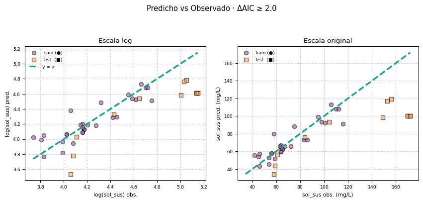

```python
import numpy as np
import pandas as pd
from pathlib import Path
from sklearn.linear_model import LinearRegression
from sklearn.model_selection import GroupKFold
from sklearn.metrics import mean_squared_error, r2_score
import matplotlib.pyplot as plt
from IPython.display import display, Markdown

# -------------------------------------------------------------
# 1 · CONFIGURACIÓN
DATOS      = Path("datos/datos_sol_sus_acolite.csv")   # ← ajusta si hace falta
DELTA_AIC  = 2.0                                       # ∆AIC mínimo entre pasos
N_BOOT     = 2000                                      # réplicas bootstrap agrupado
RNG_SEED   = 42

# -------------------------------------------------------------
# 2 · FUNCIONES AUXILIARES
def aic_gauss(rss: float, n: int, k: int) -> float:
    return n * np.log(rss / n) + 2 * k

def fit_metrics(X: np.ndarray, y: np.ndarray):
    m = LinearRegression().fit(X, y)
    pred = m.predict(X)
    rss = np.sum((y - pred) ** 2)
    n, p = X.shape
    r2 = r2_score(y, pred)
    return {
        "AIC": aic_gauss(rss, n, p + 1),
        "RMSE": np.sqrt(mean_squared_error(y, pred)),
        "R²": r2,
        "R²aj": 1 - (1 - r2) * (n - 1) / (n - p - 1),
        "mod": m
    }

rmse = lambda a, b: np.sqrt(mean_squared_error(a, b))

# -------------------------------------------------------------
# 3 · CARGA Y PREPARACIÓN
df = pd.read_csv(DATOS)
df["fecha"] = pd.to_datetime(df["fecha"])

bandas = [c for c in df.columns if c.startswith("B")]
mask = (df["sol_sus"] > 0) & (df[bandas] > 0).all(axis=1)
df = df.loc[mask].copy()

df["log_sol_sus"] = np.log(df["sol_sus"])

log_bands = []
for b in bandas:
    col = f"log_{b}"
    df[col] = np.log(df[b])
    log_bands.append(col)

req = {"B03","B04","B05","B08","B11"}
faltan = req - set(df.columns)
if faltan:
    raise ValueError(f"Faltan bandas necesarias: {faltan}")

df["NDVI"]    = (df["B08"] - df["B04"]) / (df["B08"] + df["B04"])
df["TurbI1"]  = df["B03"] / df["B04"]
df["RE_NDVI"] = (df["B08"] - df["B05"]) / (df["B08"] + df["B05"])
df["NDMI"]    = (df["B08"] - df["B11"]) / (df["B08"] + df["B11"])

indices = ["NDVI", "TurbI1", "RE_NDVI", "NDMI"]

vars_candidatas = log_bands + indices
display(Markdown(f"**Total de variables candidatas:** {len(vars_candidatas)}"))

X = df[vars_candidatas]
y = df["log_sol_sus"]

# -------------------------------------------------------------
# 4 · HOLD‑OUT TEMPORAL
last_date = df["fecha"].max()
mask_te = df["fecha"] == last_date
mask_tr = ~mask_te

X_tr, y_tr = X.loc[mask_tr], y.loc[mask_tr]
X_te, y_te = X.loc[mask_te], y.loc[mask_te]
groups_tr = df.loc[mask_tr, "fecha"]

display(Markdown(f"**TRAIN campañas:** {groups_tr.nunique()}"))
display(Markdown(f"**TEST campaña:** {last_date.date()}  ({mask_te.sum()} muestras)"))

# -------------------------------------------------------------
# 5 · FORWARD SELECTION guiado por AIC
remaining = vars_candidatas.copy()
selected = []

rss_null = np.sum((y_tr - y_tr.mean()) ** 2)
best_aic = aic_gauss(rss_null, len(y_tr), k=1)

hist = []
step = 0

while remaining:
    candidatos = []
    for v in remaining:
        cols = selected + [v]
        met = fit_metrics(X_tr[cols].values, y_tr.values)
        candidatos.append((met["AIC"], v, met))
    candidatos.sort(key=lambda t: t[0])

    new_aic, best_var, best_met = candidatos[0]
    if best_aic - new_aic >= DELTA_AIC:
        selected.append(best_var)
        remaining.remove(best_var)
        best_aic = new_aic
        step += 1
        hist.append({
            "Paso": step,
            "Variables": ", ".join(selected),
            "AIC": best_aic,
            "RMSE": best_met["RMSE"],
            "R²": best_met["R²"],
            "R²aj": best_met["R²aj"]
        })
    else:
        break

if not selected:
    best_aic, best_var, best_met = min(candidatos, key=lambda t: t[0])
    selected = [best_var]
    hist = [{
        "Paso": 1,
        "Variables": best_var,
        "AIC": best_aic,
        **{k: best_met[k] for k in ("RMSE", "R²", "R²aj")}
    }]

hist_df = pd.DataFrame(hist, columns=["Paso", "Variables", "AIC", "RMSE", "R²", "R²aj"])

display(
    hist_df.style
    .format({"AIC": "{:.3f}", "RMSE": "{:.3f}", "R²": "{:.3f}", "R²aj": "{:.3f}"})
    .set_caption("Historial de selección")
    .hide(axis="index")
)

display(Markdown(f"**Variables finales seleccionadas:** `{', '.join(selected)}`"))

# -------------------------------------------------------------
# 6 · VALIDACIÓN GROUP‑KFOLD
gkf = GroupKFold(n_splits=min(5, groups_tr.nunique()))
rmse_cv = []
for tr_idx, te_idx in gkf.split(X_tr[selected], y_tr, groups_tr):
    m = LinearRegression().fit(X_tr.iloc[tr_idx][selected], y_tr.iloc[tr_idx])
    rmse_cv.append(rmse(y_tr.iloc[te_idx], m.predict(X_tr.iloc[te_idx][selected])))

display(Markdown(f"**GroupKFold CV (log) RMSE:** {np.mean(rmse_cv):.3f} ± {np.std(rmse_cv):.3f}"))

# -------------------------------------------------------------
# 7 · MODELO FINAL Y MÉTRICAS
mod = LinearRegression().fit(X_tr[selected], y_tr)

pred_tr_log = mod.predict(X_tr[selected])
pred_te_log = mod.predict(X_te[selected])

metrics_df = pd.DataFrame({
    "Métrica": ["RMSE", "R²"],
    "Train log": [rmse(y_tr, pred_tr_log), r2_score(y_tr, pred_tr_log)],
    "Test log": [rmse(y_te, pred_te_log), r2_score(y_te, pred_te_log)],
    "Train orig": [rmse(np.exp(y_tr), np.exp(pred_tr_log)), r2_score(np.exp(y_tr), np.exp(pred_tr_log))],
    "Test orig": [rmse(np.exp(y_te), np.exp(pred_te_log)), r2_score(np.exp(y_te), np.exp(pred_te_log))]
})

display(
    metrics_df.style
    .format({
        "Train log": "{:.3f}", "Test log": "{:.3f}",
        "Train orig": "{:.3f}", "Test orig": "{:.3f}"
    })
    .set_caption("Métricas finales")
    .hide(axis="index")
)

# -------------------------------------------------------------
# 8 · BOOTSTRAP AGRUPADO (IC 95 %)
rng = np.random.default_rng(RNG_SEED)
dates = groups_tr.unique()
coef_bs = []

for _ in range(N_BOOT):
    samp = rng.choice(dates, len(dates), replace=True)
    idx = groups_tr.isin(samp)
    m_bs = LinearRegression().fit(X_tr.loc[idx, selected], y_tr.loc[idx])
    coef_bs.append(m_bs.coef_)

coef_bs = np.array(coef_bs)
mean_bs = coef_bs.mean(axis=0)
ci_bs = np.percentile(coef_bs, [2.5, 97.5], axis=0)

bs_df = pd.DataFrame({
    "Variable": selected,
    "Media β": mean_bs,
    "IC 95% inf.": ci_bs[0],
    "IC 95% sup.": ci_bs[1]
})

display(
    bs_df.style
    .format({
        "Media β": "{:.4f}",
        "IC 95% inf.": "{:.4f}",
        "IC 95% sup.": "{:.4f}"
    })
    .set_caption("Bootstrap (coeficientes, 95 % CI)")
    .hide(axis="index")
)

# -------------------------------------------------------------
# 9 · ECUACIONES
alpha = np.exp(mod.intercept_)
expr_log = " + ".join([f"{c:.4f}·{v}" for c, v in zip(mod.coef_, selected)])
expr_orig = " · ".join([f"{v}^{c:.4f}" for c, v in zip(mod.coef_, selected)])

display(Markdown("Ecuación (log)"))
display(Markdown(f"`log(sol_sus) = {mod.intercept_:.4f} + {expr_log}`"))

display(Markdown("Ecuación (original)"))
display(Markdown(f"`sol_sus = {alpha:.4f} · {expr_orig}`"))

# -------------------------------------------------------------
# 10 · GRÁFICAS DE PARIDAD (TRAIN + TEST) con estilo de colores y leyenda

plt.rcParams.update({
    "axes.titlesize": 10,
    "axes.labelsize": 8,
    "xtick.labelsize": 7,
    "ytick.labelsize": 7
})

TRAIN_CLR = "#9D50A6"
TEST_CLR = "#FFA24B"
ID_CLR = "#17A77E"

fig, ax = plt.subplots(1, 2, figsize=(9, 4))

# Escala log
ax[0].scatter(y_tr, pred_tr_log, alpha=0.6, color=TRAIN_CLR, edgecolor="k", label="Train (●)")
ax[0].scatter(y_te, pred_te_log, alpha=0.6, color=TEST_CLR, marker="s", edgecolor="k", label="Test  (■)")
lims = [min(y_tr.min(), y_te.min()), max(y_tr.max(), y_te.max())]
ax[0].plot(lims, lims, "--", color=ID_CLR, lw=2.5, label="y = x")
ax[0].set(xlabel="log(sol_sus) obs.", ylabel="log(sol_sus) pred.", title="Escala log")
ax[0].legend(fontsize=7, frameon=False)
ax[0].grid(ls=":")

# Escala original
y_tr_lin, y_te_lin = np.exp(y_tr), np.exp(y_te)
pred_tr_lin, pred_te_lin = np.exp(pred_tr_log), np.exp(pred_te_log)

ax[1].scatter(y_tr_lin, pred_tr_lin, alpha=0.6, color=TRAIN_CLR, edgecolor="k", label="Train (●)")
ax[1].scatter(y_te_lin, pred_te_lin, alpha=0.6, color=TEST_CLR, marker="s", edgecolor="k", label="Test  (■)")
lims_o = [min(y_tr_lin.min(), y_te_lin.min(), pred_tr_lin.min(), pred_te_lin.min()),
          max(y_tr_lin.max(), y_te_lin.max(), pred_tr_lin.max(), pred_te_lin.max())]
ax[1].plot(lims_o, lims_o, "--", color=ID_CLR, lw=2.5)
ax[1].set(xlabel="sol_sus obs. (mg/L)", ylabel="sol_sus pred. (mg/L)", title="Escala original")
ax[1].legend(fontsize=7, frameon=False)
ax[1].grid(ls=":")

fig.suptitle(f"Predicho vs Observado · ΔAIC ≥ {DELTA_AIC}", fontsize=11, y=1.05)
fig.tight_layout(pad=1.2)
plt.show()

# Restaurar configuración original para otras gráficas
plt.rcParams.update({
    "axes.titlesize": 11,
    "axes.labelsize": 9,
    "xtick.labelsize": 8,
    "ytick.labelsize": 8
})
```

### 2.12 todo junto

**Código**

**Total variables candidatas:** 95

**TRAIN campañas:** 5

**TEST campaña:** 2025-06-09 (12 muestras)

Tabla 28: Historial de selección

| Paso | Variables | AIC | RMSE | R² | R²aj |
| --- | --- | --- | --- | --- | --- |
| 1 | log(B02/B07) | -106.889 | 0.148 | 0.739 | 0.729 |
| 2 | log(B02/B07), log_B8A^3 | -114.331 | 0.126 | 0.812 | 0.797 |

**Variables finales seleccionadas:** `log(B02/B07), log_B8A^3`

**GroupKFold CV (log) RMSE:** 0.123 ± 0.034

Tabla 29: Métricas finales

| Métrica | Train log | Test log | Train orig | Test orig |
| --- | --- | --- | --- | --- |
| RMSE | 0.126 | 0.244 | 8.384 | 33.133 |
| R² | 0.812 | 0.688 | 0.849 | 0.490 |

Tabla 30: Bootstrap (coeficientes, 95 % CI)

| Variable | Media β | IC 95% inf. | IC 95% sup. |
| --- | --- | --- | --- |
| log(B02/B07) | -0.7848 | -0.9849 | -0.0678 |
| log_B8A^3 | -0.0036 | -0.0075 | 0.0085 |

Ecuación (log)

`log(sol_sus) = 4.1224 + -0.8370·log(B02/B07) + -0.0044·log_B8A^3`

Ecuación (original)

`sol_sus = 61.7089 · log(B02/B07)^-0.8370 · log_B8A^3^-0.0044`

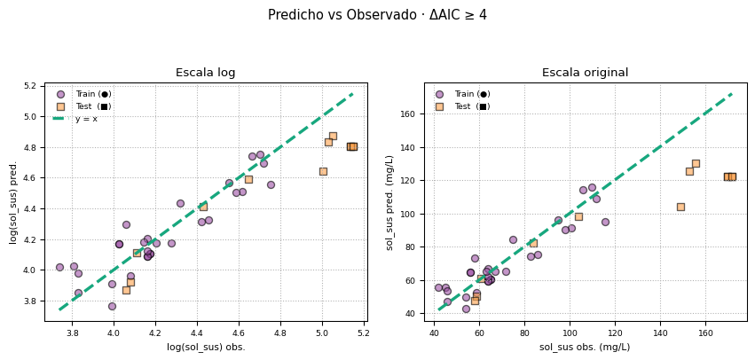

```python
import numpy as np
import pandas as pd
from pathlib import Path
from itertools import combinations
from sklearn.linear_model import LinearRegression
from sklearn.model_selection import GroupKFold
from sklearn.metrics import mean_squared_error, r2_score
import matplotlib.pyplot as plt
from IPython.display import display, Markdown

# -------------------------------------------------------------
# 1 · CONFIGURACIÓN
DATOS      = Path("datos/datos_sol_sus_acolite.csv")
DELTA_AIC  = 4
N_BOOT     = 2000
RNG_SEED   = 42

# -------------------------------------------------------------
# 2 · FUNCIONES AUXILIARES
def aic_gauss(rss, n, k):
    return n*np.log(rss/n) + 2*k

def fit_metrics(X, y):
    m = LinearRegression().fit(X, y)
    pred = m.predict(X)
    rss = np.sum((y - pred)**2)
    n, p = X.shape
    r2 = r2_score(y, pred)
    return {
        "AIC": aic_gauss(rss, n, p+1),
        "RMSE": np.sqrt(mean_squared_error(y, pred)),
        "R²": r2,
        "R²aj": 1 - (1 - r2) * (n - 1) / (n - p - 1),
        "mod": m
    }

rmse = lambda a,b: np.sqrt(mean_squared_error(a,b))

# -------------------------------------------------------------
# 3 · LECTURA Y PRE‑PROCESADO
df = pd.read_csv(DATOS)
df["fecha"] = pd.to_datetime(df["fecha"])

bandas = [c for c in df.columns if c.startswith("B")]
df = df.loc[(df["sol_sus"] > 0) & (df[bandas] > 0).all(axis=1)].copy()

df["log_sol_sus"] = np.log(df["sol_sus"])

# -------------------------------------------------------------
# 3.1 · log(Bx) y potencias
log_cols, poly_cols = [], []
for b in bandas:
    lb = f"log_{b}"
    df[lb] = np.log(df[b])
    df[f"{lb}^2"] = df[lb]**2
    df[f"{lb}^3"] = df[lb]**3
    log_cols.append(lb)
    poly_cols.extend([f"{lb}^2", f"{lb}^3"])

# -------------------------------------------------------------
# 3.2 · razones generales log(Bi/Bj)
ratio_cols = []
for i, b1 in enumerate(bandas):
    for b2 in bandas[i+1:]:
        col = f"log({b1}/{b2})"
        df[col] = df[f"log_{b1}"] - df[f"log_{b2}"]
        ratio_cols.append(col)

# -------------------------------------------------------------
# 3.3 · cocientes y índices espectrales
df["log_NIR_Blue"]  = df["log_B08"] - df["log_B02"]
df["log_Red_Green"] = df["log_B04"] - df["log_B03"]
cq_cols = ["log_NIR_Blue", "log_Red_Green"]

eps = 1e-10
df["NDVI"]   = (df["B08"] - df["B04"]) / (df["B08"] + df["B04"] + eps)
df["TurbI1"] = df["B04"] / (df["B03"] + eps)
df["RE_NDVI"]= (df["B08"] - df["B06"]) / (df["B08"] + df["B06"] + eps)
df["NDMI"]   = (df["B08"] - df["B11"]) / (df["B08"] + df["B11"] + eps)
df["NDWI"]   = (df["B03"] - df["B08"]) / (df["B03"] + df["B08"] + eps)
idx_cols = ["NDVI", "TurbI1", "RE_NDVI", "NDMI", "NDWI"]

# -------------------------------------------------------------
# 3.4 · conjunto total de candidatos
cand_cols = log_cols + poly_cols + ratio_cols + cq_cols + idx_cols

display(Markdown(f"**Total variables candidatas:** {len(cand_cols)}"))

X = df[cand_cols]
y = df["log_sol_sus"]

# -------------------------------------------------------------
# 4 · HOLD‑OUT TEMPORAL
last = df["fecha"].max()
m_te = df["fecha"] == last
m_tr = ~m_te

X_tr, y_tr = X.loc[m_tr], y.loc[m_tr]
X_te, y_te = X.loc[m_te], y.loc[m_te]
groups_tr  = df.loc[m_tr, "fecha"]

display(Markdown(f"**TRAIN campañas:** {groups_tr.nunique()}"))
display(Markdown(f"**TEST campaña:** {last.date()}  ({m_te.sum()} muestras)"))

# -------------------------------------------------------------
# 5 · FORWARD‑AIC (Δ ≥ {DELTA_AIC})
remaining, selected = cand_cols.copy(), []

rss0 = np.sum((y_tr - y_tr.mean())**2)
best_aic = aic_gauss(rss0, len(y_tr), 1)

hist, step = [], 0
while remaining:
    scores = []
    for col in remaining:
        cols = selected + [col]
        mtr = fit_metrics(X_tr[cols].values, y_tr.values)
        scores.append((mtr["AIC"], col, mtr))
    scores.sort()
    new_aic, best_col, m_info = scores[0]

    if best_aic - new_aic >= DELTA_AIC:
        selected.append(best_col)
        remaining.remove(best_col)
        best_aic = new_aic
        step += 1
        hist.append({
            "Paso": step,
            "Variables": ", ".join(selected),
            "AIC": best_aic,
            "RMSE": m_info["RMSE"],
            "R²": m_info["R²"],
            "R²aj": m_info["R²aj"]
        })
    else:
        break

if not selected:
    best_col = min(scores, key=lambda t: t[0])[1]
    selected = [best_col]
    hist.append({
        "Paso": 1,
        "Variables": best_col,
        **{k: v for k, v in scores[0][2].items() if k != "mod"}
    })

hist_df = pd.DataFrame(hist, columns=["Paso", "Variables", "AIC", "RMSE", "R²", "R²aj"])

display(
    hist_df.style
    .format({"AIC": "{:.3f}", "RMSE": "{:.3f}", "R²": "{:.3f}", "R²aj": "{:.3f}"})
    .set_caption("Historial de selección")
    .hide(axis="index")
)

display(Markdown(f"**Variables finales seleccionadas:** `{', '.join(selected)}`"))

# -------------------------------------------------------------
# 6 · VALIDACIÓN Group‑KFold
gkf = GroupKFold(n_splits=min(5, groups_tr.nunique()))
rm = []
for tr_idx, te_idx in gkf.split(X_tr[selected], y_tr, groups_tr):
    m = LinearRegression().fit(X_tr.iloc[tr_idx][selected], y_tr.iloc[tr_idx])
    rm.append(rmse(y_tr.iloc[te_idx], m.predict(X_tr.iloc[te_idx][selected])))

display(Markdown(f"**GroupKFold CV (log) RMSE:** {np.mean(rm):.3f} ± {np.std(rm):.3f}"))

# -------------------------------------------------------------
# 7 · MODELO FINAL Y MÉTRICAS
mod = LinearRegression().fit(X_tr[selected], y_tr)

pred_tr = mod.predict(X_tr[selected])
pred_te = mod.predict(X_te[selected])

metrics_df = pd.DataFrame({
    "Métrica": ["RMSE", "R²"],
    "Train log": [rmse(y_tr, pred_tr), r2_score(y_tr, pred_tr)],
    "Test log": [rmse(y_te, pred_te), r2_score(y_te, pred_te)],
    "Train orig": [rmse(np.exp(y_tr), np.exp(pred_tr)), r2_score(np.exp(y_tr), np.exp(pred_tr))],
    "Test orig": [rmse(np.exp(y_te), np.exp(pred_te)), r2_score(np.exp(y_te), np.exp(pred_te))]
})

display(
    metrics_df.style
    .format({
        "Train log": "{:.3f}", "Test log": "{:.3f}",
        "Train orig": "{:.3f}", "Test orig": "{:.3f}"
    })
    .set_caption("Métricas finales")
    .hide(axis="index")
)

# -------------------------------------------------------------
# 8 · BOOTSTRAP AGRUPADO (IC 95%)
rng = np.random.default_rng(RNG_SEED)
dates = groups_tr.unique()
coef_bs = []

for _ in range(N_BOOT):
    samp = rng.choice(dates, len(dates), replace=True)
    idx = groups_tr.isin(samp)
    m_bs = LinearRegression().fit(X_tr.loc[idx, selected], y_tr.loc[idx])
    coef_bs.append(m_bs.coef_)

coef_bs = np.array(coef_bs)
ci_lo, ci_hi = np.percentile(coef_bs, [2.5, 97.5], axis=0)

bs_df = pd.DataFrame({
    "Variable": selected,
    "Media β": coef_bs.mean(axis=0),
    "IC 95% inf.": ci_lo,
    "IC 95% sup.": ci_hi
})

display(
    bs_df.style
    .format({
        "Media β": "{:.4f}",
        "IC 95% inf.": "{:.4f}",
        "IC 95% sup.": "{:.4f}"
    })
    .set_caption("Bootstrap (coeficientes, 95 % CI)")
    .hide(axis="index")
)

# -------------------------------------------------------------
# 9 · ECUACIÓN DEL MODELO
alpha = np.exp(mod.intercept_)
expr_log = " + ".join([f"{c:.4f}·{v}" for c, v in zip(mod.coef_, selected)])
expr_orig = " · ".join([f"{v}^{c:.4f}" for c, v in zip(mod.coef_, selected)])

display(Markdown("Ecuación (log)"))
display(Markdown(f"`log(sol_sus) = {mod.intercept_:.4f} + {expr_log}`"))

display(Markdown("Ecuación (original)"))
display(Markdown(f"`sol_sus = {alpha:.4f} · {expr_orig}`"))

# -------------------------------------------------------------
# 10 · PARIDAD TRAIN + TEST (log y mg/L) con estilo colores y leyenda
plt.rcParams.update({
    "axes.titlesize": 10,
    "axes.labelsize": 8,
    "xtick.labelsize": 7,
    "ytick.labelsize": 7
})

TRAIN_CLR = "#9D50A6"
TEST_CLR = "#FFA24B"
ID_CLR = "#17A77E"

fig, ax = plt.subplots(1, 2, figsize=(9, 4))

# Escala log
ax[0].scatter(y_tr, pred_tr, alpha=0.6, color=TRAIN_CLR, edgecolor="k", label="Train (●)")
ax[0].scatter(y_te, pred_te, alpha=0.6, color=TEST_CLR, marker="s", edgecolor="k", label="Test  (■)")
lims = [min(y_tr.min(), y_te.min()), max(y_tr.max(), y_te.max())]
ax[0].plot(lims, lims, "--", color=ID_CLR, lw=2.5, label="y = x")
ax[0].set(xlabel="log(sol_sus) obs.", ylabel="log(sol_sus) pred.", title="Escala log")
ax[0].legend(fontsize=7, frameon=False)
ax[0].grid(ls=":")

# Escala original
y_tr_lin, y_te_lin = np.exp(y_tr), np.exp(y_te)
pred_tr_lin, pred_te_lin = np.exp(pred_tr), np.exp(pred_te)

ax[1].scatter(y_tr_lin, pred_tr_lin, alpha=0.6, color=TRAIN_CLR, edgecolor="k", label="Train (●)")
ax[1].scatter(y_te_lin, pred_te_lin, alpha=0.6, color=TEST_CLR, marker="s", edgecolor="k", label="Test  (■)")
lims_o = [min(y_tr_lin.min(), y_te_lin.min(), pred_tr_lin.min(), pred_te_lin.min()),
          max(y_tr_lin.max(), y_te_lin.max(), pred_tr_lin.max(), pred_te_lin.max())]
ax[1].plot(lims_o, lims_o, "--", color=ID_CLR, lw=2.5)
ax[1].set(xlabel="sol_sus obs. (mg/L)", ylabel="sol_sus pred. (mg/L)", title="Escala original")
ax[1].legend(fontsize=7, frameon=False)
ax[1].grid(ls=":")

fig.suptitle(f"Predicho vs Observado · ΔAIC ≥ {DELTA_AIC}", fontsize=11, y=1.05)
fig.tight_layout(pad=1.2)
plt.show()

plt.rcParams.update({
    "axes.titlesize": 11,
    "axes.labelsize": 9,
    "xtick.labelsize": 8,
    "ytick.labelsize": 8
})
```

## Referencias

[1]

D. C. R. Ramírez, «Método de Estimación de Sólidos Suspendidos Totales como Indicador de la Calidad del Agua Mediante Imágenes Satelitales». Universidad Nacional de Colombia, Facultad de Ciencias Agrarias, 2017.

[2]

G. D. J. L., J. Stephan, y Delance-Martinic., «Determinación del parámetro sólidos suspendidos totales (sst) mediante imágenes de sensores ópticos en un tramo de la cuenca media del río Bogotá (Colombia).», *UD y la Geomática*, pp. 19-27, 2014, doi: 10.14483/udistrital.jour.udgeo.2014.9.a02.

[3]

A. Cruz-Retana, C. Fonseca-Ortiz, R. Becerril-Piña, M. A. Gómez-Albores, M. Hernández-Téllez, y R. Arévalo-Mejia, «Characterization of spectral reflectance and TSS concentration in continental water bodies worldwide», vol. 1. pp. 4-18, 2023.

[4]

E. E. C. Vargas, «Modelamiento de Relaciones entre Parámetros Fisicoquímicos y Microbiológicos en Aguas de la Bahía Interior del Lago Titicaca-Puno (Perú) mediante Árboles de Predicción», *Revista Tecnica De La Facultad De Ingenieria Universidad Del Zulia*, vol. 44, pp. 154-168, ago. 2021, doi: 10.22209/rt.v44n3a02.

[5]

M. Moeini, A. Shojaeizadeh, y M. Geza, «Supervised machine learning for estimation of total suspended solids in urban watersheds», *Water (Switzerland)*, vol. 13, ene. 2021, doi: 10.3390/w13020147.

[6]

L. S. Kupssinskü, T. T. Guimarães, E. M. D. Souza, y D. C. Zanotta, «A method for chlorophyll-a and suspended solids prediction through remote sensing and machine learning», *Sensors (Switzerland)*, vol. 20, abr. 2020, doi: 10.3390/s20072125.

## Notas

[^1]: Aguas lénticas.
[^2]: d = prueba estadística de **Durbin-Watson**.